# Predicting Mental Health Problems from Social Determinants of Health and Caregiving Activities of Caregivers of Persons with Dementia: A Machine Learning Approach

BMIN503/EPID600 Final Project

Author

Hannah Cho

# 1 Overview

In the United States, as of 2021, approximately 34 million informal caregivers were providing unpaid support to persons living with dementia (PLWD). As dementia progresses to its end-stage or terminal phase, individuals with the condition often become fully dependent on caregivers for assistance with most daily activities, such as bathing, repositioning, and other essential personal care needs. Notably, 80% of PLWD receive care from informal caregivers—primarily spouses, adult children, and close friends—within community settings rather than institutionalized environments. The project addressed public health issues related to dementia caregiving, which directly affect caregivers’ emotional problems, such as depression and anxiety, by predicting key caregiving activities and sociodemographic features of those at high risk.

This project was conducted after consultations with Dr. George Demiris, a recognized expert in the field of dementia care and caregiving, and Dr. Huang, an experienced biostatistician. Their contributions provided critical insights into both the substantive and methodological aspects of the research, ensuring a rigorous and well-informed approach to addressing the challenges faced by caregivers of PLWD.

# 2 Introduction

In the United States, as of 2021, 34 million informal caregivers were providing unpaid support to persons living with dementia (PLWD; Alzheimer’s Association, 2023; McCabe et al., 2016; Reinhard et al., 2023). As PLWD progress to the end-stage or terminal stage of dementia, they often become dependent on assistance for most daily activities, including bathing and changing position. Of all PLWD, 80% receive care from individuals—often spouses, adult children, and close friends—in the community (Alzheimer’s Association, 2023).

Dementia caregivers face profoundly complex and multifaceted challenges that extend beyond the physical and emotional demands of caregiving. These challenges encompass physical tasks, such as providing continuous care, assisting with activities of daily living, and managing the multifarious health complications associated with dementia. However, the toll of caregiving is not solely physical; it also places a considerable emotional burden on caregivers. Many experience elevated levels of stress, anxiety, depression, and isolation, as the exhaustive nature of caregiving leaves little opportunity for self-care or social engagement.

Caregivers for persons living with dementia (PLWD) are particularly vulnerable to anxiety and depression due to the progressive and unpredictable trajectory of the disease. This trajectory often varies significantly based on individuals’ pre-existing conditions and comorbidities, adding to caregivers’ uncertainty and emotional strain.

Beyond these personal and emotional burdens, caregivers frequently encounter substantial social and systemic barriers that hinder their ability to access necessary support. These barriers include financial strain, a lack of accessible and affordable respite care, limited awareness of available resources, and cultural or social stigmas surrounding caregiving. Furthermore, caregivers often experience isolation due to diminished social engagement, compounding the psychological toll.

This study aims to explore how specific caregiving activities, individual characteristics, and sociodemographic factors predict the likelihood of anxiety and depression in dementia caregivers. Additionally, it investigates how effectively machine learning models can forecast these mental health outcomes, offering a novel approach to identifying caregivers at greatest risk and informing targeted interventions.

**Problem Statement**: Dementia caregiving is a demanding role, often accompanied by significant psychological challenges, including anxiety and depression. However, the specific caregiving activities, caregiver characteristics, and sociodemographic factors that most strongly predict these mental health outcomes remain insufficiently understood. Furthermore, while traditional statistical approaches have provided valuable insights, the potential of machine learning models to accurately forecast anxiety and depression in dementia caregivers remains underexplored. This research aims to identify the key predictors of these mental health outcomes and evaluate the predictive accuracy of machine learning algorithms in supporting early identification and targeted interventions for at-risk caregivers.

Research Question: This research aims to identify the key predictors of mental health outcomes and evaluate the predictive accuracy of machine learning algorithms in supporting the early identification of at-risk caregivers.

# 3 Methods

## 3.1 **Dataset**:

This study used data from the National Health and Aging Trends Study (NHATS) Round 11 and the National Study of Caregiving (NSOC) Round 4, which include data collected in 2021. The NHATS is a publicly accessible dataset that includes a nationally representative sample of adults aged 65 years and older who are Medicare beneficiaries in the United States of America. The NHATS began in 2011 and included 8,245 participants who have been followed up annually since then; the study goal is to encourage research to maximize health and enhance the quality of life of older adults. The NSOC is conducted alongside the NHATS; participants in the NSOC are caregivers for older adults included in the NHATS. Both the NHATS and the NSOC were funded by the National Institute on Aging (R01AG062477; U01AG032947). When used together, the NHATS and NSOC provide valuable information on dyads of older adults receiving care and their family caregivers.

## 3.2 **Samples**:

PLWD with dementia: Probable dementia was identified based on one of the following criteria: a self-reported diagnosis of dementia or Alzheimer’s disease by a physician, a score of 2 or higher on the AD8 screening instrument administered to proxy respondents, or a score that is 1.5 standard deviations below the mean on a range of cognitive tests.Caregivers: Caregivers are identified from the NSOC and NHATS data set. Since this project specifically aims to explore caregivers of persons with dementia in the community, the sample was further filtered through dementia classification (demclass) and residency (r11dresid).

Afer retriving NHATS Round 11 and NSOC ROUND 4, I specifically selected the sample (from NHATS R11- r11demclas). And then, I merged those necessary datasets.

## 3.3 Loading Packages and Bringing Dataset

```r
#Loading necessary packages first.
library(haven) #dta file
library(dplyr) #data cleaning
library(ggplot2) #data visualization
library(gtsummary) #summary statistics
library(haven) #dta file
library(dplyr) #data cleaning
library(ggplot2) #data visualization
library(gtsummary) #summary statistics
library(Hmisc) #Pearson correlation coefficient
library(tibble)
library(kernlab)
library(randomForest)
library(glmnet)
library(xgboost)
library(vip)
library(tidymodels)
library(yardstick)
library(pROC)
library(lattice)
library(caret)
library(broom)
library(tune)
library(parsnip)
library(recipes)
library(rsample)
library(workflows)
tidymodels_prefer()
```

```r
#Bring datasets
df1 <- read_dta("~/R  HC/BMIN503_Final_Project/final final/NHATS_Round_11_SP_File_V2.dta") # dementia classfication in this file
df2 <- read_dta("~/R  HC/BMIN503_Final_Project/final final/NSOC_r11.dta") #caregiver information 1
df3 <- read_dta("~/R  HC/BMIN503_Final_Project/final final/NSOC_cross.dta") #caregiver information 2
df4 <- read_dta("~/R  HC/BMIN503_Final_Project/final final/NHATS_Round_11_OP_File.dta") #older adults information
```

## 3.4 Choosing Probable and Possible Dementia Participants

```r
#need to clean df1 first in order to classify dementia classes
#ENTER WHICH ROUND?
sp1 <- df1 |>
  mutate(rnd = 11)

#3. EDIT ROUND NUMBER INSIDE THE QUOTES
#(THIS REMOVES THE PREFIXES ON NEEDED VARIABLES )
sp1 <- sp1 |>
  rename_all(~stringr::str_replace(.,"^r11","")) |>
  rename_all(~stringr::str_replace(.,"^hc11","")) |>
  rename_all(~stringr::str_replace(.,"^is11","")) |>
  rename_all(~stringr::str_replace(.,"^cp11","")) |>
  rename_all(~stringr::str_replace(.,"^cg11",""))

#ADD R1DAD8DEM AND SET TO -1 FOR ROUND 1 BECAUSE THERE IS NO PRIOR DIAGNOSIS IN R1
sp1 <- sp1 |>
  mutate(dad8dem = ifelse(rnd == 1, -1, dad8dem))


#ADD R1DAD8DEM AND SET TO -1 FOR ROUND 1 BECAUSE THERE IS NO PRIOR DIAGNOSIS IN R1
sp1 <- sp1 |>
  mutate(dad8dem = ifelse(rnd == 1, -1, dad8dem))

#SUBSET NEEDED VARIABLES
df<-sp1 |>
  dplyr::select(spid, rnd, dresid, resptype, disescn9, chgthink1, chgthink2, chgthink3, chgthink4, chgthink5, chgthink6, chgthink7, chgthink8, dad8dem,
                speaktosp, todaydat1, todaydat2, todaydat3, todaydat4, todaydat5, presidna1, presidna3, vpname1, vpname3, quesremem, dclkdraw, atdrwclck,
                dwrdimmrc, dwrdlstnm, dwrddlyrc)

#FIX A ROUND 2 CODING ERROR#
df <- df |>
  mutate(dwrdimmrc = ifelse(dwrdimmrc==10 & dwrddlyrc==-3 & rnd==2, -3, dwrdimmrc))

#CREATE SELECTED ROUND DEMENTIA CLASSIFICATION VARIABLE
df <- df |>
  mutate(demclas  =  ifelse(dresid==3 | dresid==5 | dresid==7, -9, #SET MISSING (RESIDENTIAL CARE FQ ONLY) AND N.A. (NURSING HOME RESIDENTS, DECEASED)
                            ifelse((dresid==4 & rnd==1) | dresid==6 | dresid==8, -1,                #SET MISSING (RESIDENTIAL CARE FQ ONLY) AND N.A. (NURSING HOME RESIDENTS, DECEASED)
                                   ifelse((disescn9==1 | disescn9==7) &           #CODE PROBABLE IF DEMENTIA DIAGNOSIS REPORTED BY SELF OR PROXY*
                                            (resptype==1 | resptype==2), 1, NA))))

#CODE AD8_SCORE*
#INITIALIZE COUNTS TO NOT APPLICABLE*
#ASSIGN VALUES TO AD8 ITEMS IF PROXY AND DEMENTIA CLASS NOT ALREADY ASSIGNED BY REPORTED DIAGNOSIS
for(i in 1:8){
  df[[paste("ad8_", i, sep = "")]]  <- as.numeric(ifelse(df[[paste("chgthink", i, sep = "")]]==2 & df$resptype==2 & is.na(df$demclas), 0, #PROXY REPORTS NO CHANGE
                                                         ifelse((df[[paste("chgthink", i, sep = "")]]==1 | df[[paste("chgthink", i, sep = "")]] == 3) & df$resptype==2 & is.na(df$demclas), 1, #PROXY REPORTS A CHANGE OR ALZ/DEMENTIA*
                                                                ifelse(df$resptype==2 & is.na(df$demclas), NA, -1))))    #SET TO NA IF IN RES CARE AND demclass=., OTHERWISE AD8 ITEM IS SET TO NOT APPLICABLE
}

#INITIALIZE COUNTS TO NOT APPLICABLE*
for(i in 1:8){
  df[[paste("ad8miss_", i, sep = "")]]  <- as.numeric(ifelse(is.na(df[[paste("ad8_", i, sep = "")]]), 1,
                                                             ifelse((df[[paste("ad8_", i, sep = "")]]==0 | df[[paste("ad8_", i, sep = "")]]==1) & df$resptype==2 & is.na(df$demclas), 0, -1)))
}

for(i in 1:8){
  df[[paste("ad8_", i, sep = "")]] <- as.numeric(ifelse(is.na(df[[paste("ad8_", i, sep = "")]]) & is.na(df$demclas) & df$resptype==2, 0, df[[paste("ad8_", i, sep = "")]]))
}

#COUNT AD8 ITEMS
#ROUNDS 2+
df <- df |>
  mutate(ad8_score = ifelse(resptype==2 & is.na(demclas), (ad8_1 + ad8_2 + ad8_3 + ad8_4 + ad8_5 + ad8_6 + ad8_7 + ad8_8), -1)) %>%
  #SET PREVIOUS ROUND DEMENTIA DIAGNOSIS BASED ON AD8 TO AD8_SCORE=8
  mutate(ad8_score = ifelse(dad8dem==1 & resptype==2 & is.na(demclas), 8, ad8_score))  %>%
  #SET PREVIOUS ROUND DEMENTIA DIAGNOSIS BASED ON AD8 TO AD8_SCORE=8 FOR ROUNDS 4-9
  mutate(ad8_score = ifelse(resptype==2 & dad8dem==-1 & chgthink1==-1 & (rnd>=4 & rnd<=9) & is.na(demclas) , 8, ad8_score))

#COUNT MISSING AD8 ITEMS
df <- df |>
  mutate(ad8_miss = ifelse(resptype==2 & is.na(demclas),(ad8miss_1+ad8miss_2+ad8miss_3+ad8miss_4+ad8miss_5+ad8miss_6+ad8miss_7+ad8miss_8), -1))

#CODE AD8 DEMENTIA CLASS
#IF SCORE>=2 THEN MEETS AD8 CRITERIA
#IF SCORE IS 0 OR 1 THEN DOES NOT MEET AD8 CRITERIA
df <- df |>
  mutate(ad8_dem = ifelse(ad8_score>=2, 1,
                          ifelse(ad8_score==0 | ad8_score==1 | ad8_miss==8, 2, NA)))

#UPDATE DEMENTIA CLASSIFICATION VARIABLE WITH AD8 CLASS
df <- df |>
  #PROBABLE DEMENTIA BASED ON AD8 SCORE
  mutate(demclas = ifelse(ad8_dem==1 & is.na(demclas), 1,
                          #NO DIAGNOSIS, DOES NOT MEET AD8 CRITERION, AND PROXY SAYS CANNOT ASK SP COGNITIVE ITEMS*
                          ifelse(ad8_dem==2 & speaktosp==2 & is.na(demclas), 3, demclas)))


####CODE DATE ITEMS AND COUNT
#CODE ONLY YES/NO RESPONSES: MISSING/NA CODES -1, -9 LEFT MISSING*
#2: NO/DK OR -7: REFUSED RECODED TO : NO/DK/RF*
#****ADD NOTES HERE ABOUT WHAT IS HAPPENING IN ROUNDS 1-3, 5+ VS. ROUND 4
#*
for(i in 1:5){
  df[[paste("date_item", i, sep = "")]]  <- as.numeric(ifelse(df[[paste("todaydat", i, sep = "")]]==1, 1,
                                                              ifelse(df[[paste("todaydat", i, sep = "")]]==2 | df[[paste("todaydat", i, sep = "")]]== -7, 0, NA)))
}

#COUNT CORRECT DATE ITEMS
df <- df |>
  mutate(date_item4 = ifelse(rnd==4, date_item5, date_item4)) %>%
  mutate(date_sum = date_item1 + date_item2 + date_item3 + date_item4) %>%

  #PROXY SAYS CAN'T SPEAK TO SP
  mutate(date_sum = ifelse(speaktosp==2 & is.na(date_sum),-2,
                           #PROXY SAYS CAN SPEAK TO SP BUT SP UNABLE TO ANSWER*
                           ifelse((is.na(date_item1) | is.na(date_item2) | is.na(date_item3) | is.na(date_item4)) & speaktosp==1,-3, date_sum))) %>%

  #MISSING IF PROXY SAYS CAN'T SPEAK TO SP*
  mutate(date_sumr = ifelse(date_sum == -2 , NA,
                            #0 IF SP UNABLE TO ANSWER*
                            ifelse(date_sum == -3 , 0, date_sum)))


########PRESIDENT AND VICE PRESIDENT NAME ITEMS AND COUNT##########
##CODE ONLY YES/NO RESPONSES: MISSING/N.A. CODES -1,-9 LEFT MISSING *
##2:NO/DK OR -7:REFUSED RECODED TO 0:NO/DK/RF*
df <- df |>
  mutate(preslast = ifelse(presidna1 == 1, 1,
                           ifelse(presidna1 == 2 | presidna1 == -7, 0, NA))) |>
  mutate(presfirst = ifelse(presidna3 == 1, 1,
                            ifelse(presidna3 == 2 | presidna3 == -7, 0, NA))) |>
  mutate(vplast = ifelse(vpname1 == 1, 1,
                         ifelse(vpname1 == 2 | vpname1 == -7, 0, NA))) |>
  mutate(vpfirst = ifelse(vpname3 == 1, 1,
                          ifelse(vpname3 == 2 | vpname3 == -7, 0, NA))) |>

  #COUNT CORRECT PRESIDENT/VP NAME ITEMS*
  mutate(presvp = preslast + presfirst + vplast + vpfirst) |>
  #PROXY SAYS CAN'T SPEAK TO SP
  mutate(presvp = ifelse(speaktosp == 2 & is.na(presvp), -2,
                         #PROXY SAYS CAN SPEAK TO SP BUT SP UNABLE TO ANSWER
                         ifelse((is.na(preslast) | is.na(presfirst) | is.na(vplast) | is.na(vpfirst)) & speaktosp==1 & is.na(presvp),-3, presvp))) |>

  #MISSING IF PROXY SAYS CAN’T SPEAK TO SP*
  mutate(presvpr =  ifelse(presvp == -2 , NA,
                           ifelse(presvp == -3 , 0, presvp))) |>

  #ORIENTATION DOMAIN: SUM OF DATE RECALL AND PRESIDENT/VP NAMING*
  mutate(date_prvp = date_sumr + presvpr)


#######EXECUTIVE FUNCTION DOMAIN: CLOCK DRAWING SCORE##########
#RECODE DCLKDRAW TO ALIGN WITH MISSING VALUES IN PREVIOUS ROUNDS (ROUND 10 ONLY)*
df <- df |>
  mutate(dclkdraw = ifelse(speaktosp == 2 & dclkdraw == -9 & rnd==10, -2,
                           ifelse(speaktosp==1 & (quesremem==2 | quesremem==-7 | quesremem==-8) & dclkdraw==-9 & rnd==10, -3,
                                  ifelse(atdrwclck==2 & dclkdraw==-9 & rnd==10, -4,
                                         ifelse(atdrwclck==97 & dclkdraw==-9 & rnd==10, -7, dclkdraw)))))

#RECODE DCLKDRAW TO ALIGN WITH MISSING VALUES IN PREVIOUS ROUNDS (ROUNDS 11 AND FORWARD ONLY)*
df<-df  |>
  mutate(dclkdraw = ifelse(speaktosp == 2 & dclkdraw == -9 & rnd>=11, -2,
                           ifelse(speaktosp == 1 & (quesremem == 2 | quesremem == -7 | quesremem == -8) & dclkdraw == -9, -3 & rnd>=11, dclkdraw)))
df<-df  |>
  mutate(clock_scorer = ifelse(dclkdraw == -3 | dclkdraw == -4 | dclkdraw == -7, 0,
                               #IMPUTE MEAN SCORE TO PERSONS MISSING A CLOCK*
                               #IF PROXY SAID CAN ASK SP*
                               ifelse(dclkdraw == -9 & speaktosp == 1, 2,
                                      #IF SELF-RESPONDENT*
                                      ifelse(dclkdraw == -9 & speaktosp == -1, 3,
                                             ifelse(dclkdraw == -2 | dclkdraw == -9, NA, dclkdraw)))))


#MEMORY DOMAIN: IMMEDIATE AND DELAYED WORD RECALL
df <- df |>
  mutate(irecall  =  ifelse(dwrdimmrc == -2 | dwrdimmrc == -1, NA,
                            ifelse(dwrdimmrc == -7 | dwrdimmrc == -3, 0, dwrdimmrc))) |>
  mutate(irecall = ifelse(rnd==5 & dwrddlyrc==-9, NA, irecall)) |>  #round 5 only: set cases with missing word list and not previously assigned to missing

  mutate(drecall  =  ifelse(dwrddlyrc == -2 | dwrddlyrc == -1, NA,
                            ifelse(dwrddlyrc == -7 | dwrddlyrc == -3, 0, dwrddlyrc))) |>
  mutate(drecall = ifelse(rnd==5 & dwrddlyrc==-9, NA, drecall)) |>  #round 5 only: set cases with missing word list and not previously assigned to missing

  mutate(wordrecall0_20 = irecall+drecall)


#CREATE COGNITIVE DOMAINS FOR ALL ELIGIBLE

df<-df |>
  mutate(clock65 = ifelse(clock_scorer == 0 | clock_scorer==1, 1,
                          ifelse(clock_scorer > 1 & clock_scorer<6, 0, NA)))

df<-df |>
  mutate(word65 = ifelse(wordrecall0_20 >= 0 & wordrecall0_20 <=3, 1,
                         ifelse(wordrecall0_20 > 3 & wordrecall0_20 <=20, 0, NA)))

df<-df |>
  mutate(datena65 = ifelse(date_prvp >= 0 & date_prvp <=3, 1,
                           ifelse(date_prvp > 3 & date_prvp <= 8, 0, NA)))

#  *CREATE COGNITIVE DOMAIN SCORE*
df<-df |>
  mutate(domain65 = clock65+word65+datena65)

#*SET CASES WITH MISSING WORD LIST AND NOT PREVIOUSLY ASSIGNED TO MISSING (ROUND 5 ONLY)
df<-df |>
  mutate(demclas = ifelse(rnd==5 & dwrdlstnm==-9 & is.na(demclas), -9, demclas))

#UPDATE COGNITIVE CLASSIFICATION*
df<-df |>
  #PROBABLE DEMENTIA
  mutate(demclas = ifelse(is.na(demclas) & (speaktosp == 1 | speaktosp == -1) & (domain65==2 | domain65==3), 1,
                          #POSSIBLE DEMENTIA
                          ifelse(is.na(demclas) & (speaktosp == 1 | speaktosp == -1) & domain65==1, 2,
                                 #NO DEMENITA
                                 ifelse(is.na(demclas) & (speaktosp == 1 | speaktosp == -1) & domain65==0, 3, demclas))))

#KEEP VARIABLES AND SAVE DATA
df<-df |>
  dplyr::select(spid, rnd, demclas)

#CHANGE # AFTER "r" TO THE ROUND OF INTEREST
r11demclas <- df

#4. NAME AND SAVE DEMENTIA DATA FILE:
#CHANGE # AFTER "r" TO THE ROUND OF INTEREST
save(r11demclas, file = "~/R  HC/BMIN503_Final_Project/final final/NHATS_r11.dta")
```

## 3.5 Merging Datasets

```r
#merged datasets (md). md1 <- left_join(df, df1, by = "spid") md2 <- left_join(md1, df3, by = "spid")
#merged datasets (md).
md1 <- left_join(df, df1, by = "spid")
md2 <- left_join(md1, df3, by = "spid")

# choose probable dementia and dementia patients who live at home
dementia1 <- md2 |>
  filter(demclas %in% c("1", "2") & (r11dresid  %in% c("1")))

dementia2 <- md2 |>
  filter(demclas %in% c("1", "2") & (r11dresid  %in% c("1", "2")))
```

## 3.6 Preliminary Table Manipulation

Before creating the subset of the dataset for analysis, I will recode the variables. After reviewing the literature on dementia caregivers and social determinants of health, I selected the following variables.

### 3.6.1 **Predictors**

```r
#Race
# Recode `race` to create a new binary variable
# 1 for "White, non-Hispanic" and 0 for "Non-White"
# Recode race to create a new variable 'race_recode'
dementia1 <- dementia1 |>
  mutate(
    race_recode = case_when(
      crl11dcgracehisp == 1 ~ 0,  # White, non-Hispanic
      crl11dcgracehisp == 2 ~ 1, #black, non-hispanic
      crl11dcgracehisp == 3 ~ 2,  # others
      crl11dcgracehisp == 4 ~ 3,
      chd11educ %in% c(5, 6) ~ NA_real_, # Missing or not applicable
      TRUE ~ NA_real_                      # Unhandled cases# hispanics
    ))

table(dementia1$crl11dcgracehisp)
```

```
  1   2   3   4   5   6
250 193  16  46   1  22
```

```r
table(dementia1$race_recode)
```

```
  0   1   2   3
250 193  16  46
```

```r
# Gender: Male as reference (0), Female as 1
dementia1 <- dementia1 |>
  mutate(
    gender_recode = case_when(
      as.character(c11gender) == "1" ~ 0,  # Male
      as.character(c11gender) == "2" ~ 1,  # Female
      TRUE ~ NA_real_  # Handle any other unexpected cases
    )
  )

# Education: Recoding education levels into two categories
table(dementia1$chd11educ)
```

```
 -8  -7  -6   1   2   3   4   5   6   7   8   9
 13   1   2   1   5  36 132  35 101  50  83  69
```

```r
dementia1 <- dementia1 |>
  mutate(
    edu_recode = case_when(
      chd11educ %in% c(1, 2, 3) ~ 1,      # Below and high school diploma
      chd11educ %in% c(4, 5) ~ 1,          # Some college
      chd11educ %in% c(6, 7, 8) ~ 2,       # College and beyond
      chd11educ == c(9) ~ 3,
      chd11educ %in% c(-8, -7, -6) ~ NA_real_, # Missing or not applicable
      TRUE ~ NA_real_                      # Unhandled cases
    )
  )
table(dementia1$edu_recode)
```

```
  1   2   3
209 234  69
```

```r
# Marital Status: Recoding marital status into binary (married vs. not married)
dementia1 <- dementia1 |>
  mutate(
    martstat_recode = case_when(
      chd11martstat == 1 ~ 0,     # Married
      chd11martstat %in% 2:6 ~ 1, # Not married (single, divorced, etc.)
      chd11martstat %in% c(-8, -6) ~ NA_real_, # Missing or not applicable
      TRUE ~ NA_real_                      # Unhandled cas
    )
  )

table(dementia1$martstat_recode)
```

```
  0   1
204 232
```

```r
# preparing dataset
final_dementia <- dementia1 |>
mutate(
    race_recode = case_when(
      race_recode == 1 ~ "White, non-Hispanic",
      race_recode == 2 ~ "Black, non-Hispanic",
      race_recode == 3 ~ "Other",
      race_recode == 4 ~ "Hispanic",
      TRUE ~ NA_character_
    ),
    gender_recode = case_when(
      gender_recode == "0" ~ "Male",
      gender_recode == "1" ~ "Female",
      TRUE ~ NA_character_
    ),
    edu_recode = case_when(
      edu_recode == "1" ~ "Below high school",
      edu_recode == "2" ~ "Some college",
      edu_recode == "3" ~ "College and beyond",
      TRUE ~ NA_character_
    ),
    martstat_recode = case_when(
       martstat_recode == "2" ~ "Married",
      martstat_recode == "1" ~ "Not married",
      TRUE ~ NA_character_
    )
  )

# Dementia class -Adding labels for clarity
final_dementia$demclas_label <- factor(
final_dementia$demclas,
  levels = c(1, 2),
  labels = c("Probable Dementia", "Possible Dementia")
)

final_dementia <- final_dementia |>
  group_by(spid) |>
  slice_head(n = 1) |>
  ungroup()

#creating table, classfied by group 1 (proable dementia) and group 2 (possible dementia)
summary_table <- final_dementia |>
  select(demclas, race_recode, gender_recode, edu_recode, martstat_recode, chd11dage) |>
  tbl_summary(
    by = demclas,
    statistic = list(all_continuous() ~ "{mean} ({sd})", all_categorical() ~ "{n} ({p}%)"),
    label = list(
      race_recode ~ "Race",
      gender_recode ~ "Gender",
      edu_recode ~ "Education",
      martstat_recode ~ "Marital Status",
      chd11dage ~ "Age"
    ),
    missing_text = "(Missing)"
  ) |>
  add_p() |>  # adding p-value
  modify_header(label ~ "**Variable**") |>
  bold_labels()
```

[output not shown]

```r
# summarize
summary_table
```

| **Variable** | **1** N = 331<sup>1</sup> | **2** N = 232<sup>1</sup> | **p-value**<sup>2</sup> |
| --- | --- | --- | --- |
| Race |  |  | 0.7 |
| Black, non-Hispanic | 7 (6.2%) | 2 (5.7%) |  |
| Other | 24 (21%) | 5 (14%) |  |
| White, non-Hispanic | 82 (73%) | 28 (80%) |  |
| (Missing) | 218 | 197 |  |
| Gender |  |  | 0.4 |
| Female | 155 (71%) | 61 (66%) |  |
| Male | 64 (29%) | 32 (34%) |  |
| (Missing) | 112 | 139 |  |
| Education |  |  | 0.5 |
| Below high school | 89 (42%) | 44 (49%) |  |
| College and beyond | 27 (13%) | 9 (10%) |  |
| Some college | 96 (45%) | 37 (41%) |  |
| (Missing) | 119 | 142 |  |
| Marital Status |  |  |  |
| Not married | 83 (100%) | 41 (100%) |  |
| (Missing) | 248 | 191 |  |
| Age | 63 (19) | 62 (21) | 0.8 |
| (Missing) | 112 | 139 |  |

<sup>1</sup> n (%); Mean (SD)  
<sup>2</sup> Fisher’s exact test; Pearson’s Chi-squared test; Wilcoxon rank sum test

### 3.6.2 Caregivers’ Features

Based on a thorough examination of the literature and clinical experiences, I have identified these caregiving activities as the initial key factors to explore for predicting the mental health of caregivers. This selection is grounded in evidence from existing research and practical insights, aiming to provide a comprehensive understanding of the elements that most significantly impact caregiver well-being.

```r
dementia1 <- dementia1 |>
  mutate(across(
    c(cca11hwoftchs, cca11hwoftshp, cca11hwoftpc,
      cca11hwofthom, cca11hwoftdrv, cca11hwoftott),
  )) |>
  mutate(
    cca11hwoftchs_recoded = case_when(
      cca11hwoftchs %in% c(1, 2, 3) ~ 1,
      cca11hwoftchs %in% c(4, 5) ~ 0,
      TRUE ~ NA_real_
    ),
    cca11hwoftshp_recoded = case_when(
      cca11hwoftshp %in% c(1, 2, 3) ~ 1,
      cca11hwoftshp %in% c(4, 5) ~ 0,
      TRUE ~ NA_real_
    ),
    cca11hwoftpc_recoded = case_when(
      cca11hwoftpc %in% c(1, 2, 3) ~ 1,
      cca11hwoftpc %in% c(4, 5) ~ 0,
      TRUE ~ NA_real_
    ),
    cca11hwofthom_recoded = case_when(
      cca11hwofthom %in% c(1, 2, 3) ~ 1,
      cca11hwofthom %in% c(4, 5) ~ 0,
      TRUE ~ NA_real_
    ),
    cca11hwoftdrv_recoded = case_when(
      cca11hwoftdrv %in% c(1, 2, 3) ~ 1,
      cca11hwoftdrv %in% c(4, 5) ~ 0,
      TRUE ~ NA_real_
    ),
    cca11hwoftott_recoded = case_when(
      cca11hwoftott %in% c(1, 2, 3) ~ 1,
      cca11hwoftott %in% c(4, 5) ~ 0,
      TRUE ~ NA_real_
    )
  )


#C11 CA3 EVER HELP ORDER MEDICINES (cca11hlpordmd) - yes 1 no 2-->0
#C11 CA5A GO ONLINE billing or banking (cca11hlpbnkng)
#C11 CA5A GO ONLINE SHOP FR GROC (cca11cmpgrcry)
#C11 CA5B GO ONLINE ORDER MEDS (cca11cmpordrx )
#C11 CA5C GO ONLINE BILLS BANKNG (cca11cmpbnkng )
#C11 CA6B1 HELP CARE FOR TEETH (PREVIOUSLY CA11F) (cca11hlpteeth)
#cdc11hlpyrpls

dementia1 <- dementia1 |>
  mutate(across(
    c(cca11hlpordmd, cca11hlpbnkng, cca11cmpgrcry,
      cca11cmpordrx, cca11cmpbnkng, cca11hlpteeth,cdc11hlpyrpls),
    ~ case_when(
        . == 1 ~ 1,
        . == 2 ~ 0,
        . %in% c(-8, -6, -1) ~ NA_real_,
        TRUE ~ NA_real_
      ),
    .names = "{.col}_recoded"
  ))
```

### 3.6.3 **Outcomes**

Caregivers’ anxiety and depressive symptoms are measured by two questions each.First, anxiety was measured Generalized Anxiety Disorder-2 (GAD-2) Scale which consists of two questions. Since the NHATS provided GAD-2 data, this study utilized it to measure anxiety levels among care recipients. Each item on the scale is rated on a four-point Likert scale, ranging from 0 (not at all) to 3 (nearly every day), resulting in a total score between 0 and 6. Higher scores correspond to greater anxiety, with a total GAD-2 score of 3 or more indicating anxiety.

The care recipients’ depression was evaluated using the Patient Health Questionnaire-2 (PHQ-2) Scale. Given that the NHATS included PHQ-2, this study utilized it to measure depression in care recipients. Each item on the scale was measured with a four-point Likert scale, ranging from 0 (not at all) to 3 (nearly every day), resulting a total score between 0 and 6, with higher scores indicating more severe depression. A PHQ-2 score ranges from 0-6. The authors identified a score of 3 as the optimal cutpoint when using the PHQ-2 to screen for depression. If the score is 3 or greater, major depressive disorder is likely.

```r
# Sum the two questions for GAD2
dementia1$total_gad2 <- dementia1$che11fltnervs + dementia1$che11fltworry
# Recode the combined variable using a cut-off of 3
dementia1$gad2_cg_cat <- ifelse(dementia1$total_gad2 < 3, 0, 1)
 table(dementia1$gad2_cg_cat)
```

```
  0   1
279 249
```

```r
 summary(dementia1$gad2_cg_cat) #1 ~ anxiety
```

```
   Min. 1st Qu.  Median    Mean 3rd Qu.    Max.    NA's
 0.0000  0.0000  0.0000  0.4716  1.0000  1.0000     251
```

```r
# Sum of the two questions for PHQ2 (che11fltltlin + che11fltdown)
dementia1$total_phq2 <- dementia1$che11fltltlin+ dementia1$che11fltdown
#Recode the combined variable using a cut-off of 3
dementia1$phq2_cg_cat <- ifelse(dementia1$total_phq2 < 3, 0, 1)
 table(dementia1$phq2_cg_cat)
```

```
  0   1
276 252
```

```r
 summary(dementia1$phq2_cg_cat) #1 ~ depression
```

```
   Min. 1st Qu.  Median    Mean 3rd Qu.    Max.    NA's
 0.0000  0.0000  0.0000  0.4773  1.0000  1.0000     251
```

## 3.7 **Data analysis**

### 3.7.1 Pearson correlation matrix

```r
#choosing only one caregiver for each participant
final <- dementia1 |>
  group_by(spid) |>
  slice_head(n = 1) |>
  ungroup()

#total 563 caregivers
#creating subset to work more effectively

selected_vars <- c(
  "spid","demclas", "cca11hwoftchs", "cca11hwoftshp", "cca11hwoftpc",
  "cca11hwofthom", "cca11hwoftdrv", "cca11hwoftott",
  "che11enrgylmt", "cac11diffphy", "cac11exhaustd",
  "cac11toomuch", "cac11uroutchg", "cac11notime",
  "cac11diffemlv", "cpp11hlpkptgo", "che11health",
  "che11sleepint",
   "ew11progneed1", "ew11finhlpfam",
  "mc11havregdoc", "hc11hosptstay", "hc11hosovrnht",
  "cac11diffinc", "pa11hlkepfvst", "pa11hlkpfrclb", "pa11hlkpgoenj", "pa11hlkpfrwrk", "pa11hlkpfrvol", "pa11prcranoth", "race_recode", "gender_recode", "edu_recode", "chd11dage", "martstat_recode", "phq2_cg_cat", "gad2_cg_cat"
)

dementia_subset <- dementia1 |> select(all_of(selected_vars))
head(dementia_subset)
```

```
# A tibble: 6 × 37
      spid demclas cca11hwoftchs    cca11hwoftshp    cca11hwoftpc  cca11hwofthom
     <dbl>   <dbl> <dbl+lbl>        <dbl+lbl>        <dbl+lbl>     <dbl+lbl>
1 10000036       1 NA               NA               NA            NA
2 10000041       2  1 [1 EVERY DAY]  1 [1 EVERY DAY]  1 [1 EVERY …  1 [1 EVERY …
3 10000041       2  5 [5 NEVER]      4 [4 RARELY]     5 [5 NEVER]   3 [3 SOME D…
4 10000051       1  1 [1 EVERY DAY]  3 [3 SOME DAYS]  2 [2 MOST D…  3 [3 SOME D…
5 10000064       1  2 [2 MOST DAYS]  5 [5 NEVER]      3 [3 SOME D…  3 [3 SOME D…
6 10000064       1  1 [1 EVERY DAY]  1 [1 EVERY DAY]  5 [5 NEVER]   3 [3 SOME D…
# ℹ 31 more variables: cca11hwoftdrv <dbl+lbl>, cca11hwoftott <dbl+lbl>,
#   che11enrgylmt <dbl+lbl>, cac11diffphy <dbl+lbl>, cac11exhaustd <dbl+lbl>,
#   cac11toomuch <dbl+lbl>, cac11uroutchg <dbl+lbl>, cac11notime <dbl+lbl>,
#   cac11diffemlv <dbl+lbl>, cpp11hlpkptgo <dbl+lbl>, che11health <dbl+lbl>,
#   che11sleepint <dbl+lbl>, ew11progneed1 <dbl+lbl>, ew11finhlpfam <dbl+lbl>,
#   mc11havregdoc <dbl+lbl>, hc11hosptstay <dbl+lbl>, hc11hosovrnht <dbl+lbl>,
#   cac11diffinc <dbl+lbl>, pa11hlkepfvst <dbl+lbl>, pa11hlkpfrclb <dbl+lbl>, …
```

```r
# Select only numeric columns
numeric_dementia1 <- dementia_subset |> select(where(is.numeric))

# Compute the Pearson correlation matrix and p-values
cor_matrix <- rcorr(as.matrix(numeric_dementia1), type = "pearson")

# Extract correlation coefficients and p-values
cor_coefficients <- cor_matrix$r
p_values <- cor_matrix$P

# Print the correlation coefficients and p-values
print("Pearson Correlation Coefficients:")
```

```
[1] "Pearson Correlation Coefficients:"
```

```r
print(cor_coefficients)
```

```
                         spid       demclas cca11hwoftchs cca11hwoftshp
spid             1.0000000000  0.0524046287   0.057445651  -0.048922628
demclas          0.0524046287  1.0000000000   0.155233246   0.095219616
cca11hwoftchs    0.0574456507  0.1552332459   1.000000000   0.456601722
cca11hwoftshp   -0.0489226280  0.0952196158   0.456601722   1.000000000
cca11hwoftpc     0.0569993670  0.1768067133   0.476941147   0.277072360
cca11hwofthom    0.1262698548  0.0707709399   0.376673901   0.242529862
cca11hwoftdrv    0.0223564320  0.0003341216   0.165484423   0.323117006
cca11hwoftott   -0.0233501682 -0.0444960625   0.093940239   0.062109831
che11enrgylmt   -0.0545697848 -0.0634640518  -0.065075660  -0.072564036
cac11diffphy     0.0132632379 -0.0298232163   0.088321919   0.099560878
cac11exhaustd   -0.0176254960  0.0598313839   0.129105151   0.144879204
cac11toomuch    -0.0001725267  0.0307524721   0.103688972   0.166320039
cac11uroutchg    0.0170743560  0.0824021754   0.092613529   0.075500846
cac11notime     -0.0488704599 -0.0170096976   0.094203762   0.099913494
cac11diffemlv   -0.0222413895 -0.1490423589  -0.098726070  -0.078492761
cpp11hlpkptgo    0.0728939893  0.0239080150  -0.017595980  -0.066646199
che11health     -0.0847226688 -0.0606643378   0.011340640   0.078119084
che11sleepint   -0.0161859440  0.0386538252   0.207186255   0.190838907
ew11progneed1    0.0452717788  0.0382606781  -0.014766666   0.024810282
ew11finhlpfam   -0.0488711416 -0.0129049993   0.049851158  -0.008841781
mc11havregdoc    0.0956294871  0.0261427921  -0.016233998   0.010233936
hc11hosptstay    0.0189280798  0.0104006121   0.084372878   0.006189677
hc11hosovrnht   -0.0304200871 -0.0254815260  -0.081200178  -0.014808258
cac11diffinc    -0.0135741242  0.0195568702   0.081740617   0.112055258
pa11hlkepfvst   -0.0257610857  0.1473647589   0.033435029  -0.031017776
pa11hlkpfrclb    0.0779631058  0.1282570941   0.008741207   0.018884911
pa11hlkpgoenj    0.0619563799  0.1631145627   0.040479596   0.011612055
pa11hlkpfrwrk    0.0254381404  0.1213256322   0.065153705   0.075050974
pa11hlkpfrvol   -0.0553381018  0.0784426387  -0.010456252  -0.048530586
pa11prcranoth    0.0104238330 -0.0141994750  -0.051164198   0.007071047
race_recode      0.0274228923 -0.0979817377  -0.150829877  -0.073932070
gender_recode    0.0407394869 -0.0048522588   0.002135600  -0.008804082
edu_recode      -0.0731264786 -0.0184402463   0.164017961   0.088230754
chd11dage       -0.0148747765 -0.0142058380  -0.018536036   0.025790177
martstat_recode  0.0051907430  0.0669074383  -0.238588317  -0.163623016
phq2_cg_cat     -0.0909125017 -0.0729100465  -0.094241876  -0.017712955
gad2_cg_cat     -0.0120871734 -0.0742964016  -0.037706046  -0.046063803
                 cca11hwoftpc cca11hwofthom cca11hwoftdrv cca11hwoftott
spid             0.0569993670   0.126269855  0.0223564320 -2.335017e-02
```

[output cut: 325 more lines]

```
hc11hosovrnht    0.0132139904
cac11diffinc     0.0732970741
pa11hlkepfvst   -0.0428726645
pa11hlkpfrclb   -0.1287133679
pa11hlkpgoenj   -0.0877509691
pa11hlkpfrwrk   -0.0180222211
pa11hlkpfrvol   -0.0453954199
pa11prcranoth    0.0315445366
race_recode     -0.0532416340
gender_recode    0.0791303075
edu_recode       0.0472227533
chd11dage        0.0419603408
martstat_recode -0.0321366719
phq2_cg_cat      0.4873439035
gad2_cg_cat      1.0000000000
```

```r
print("P-Values:")
```

```
[1] "P-Values:"
```

```r
print(p_values)
```

```
                       spid      demclas cca11hwoftchs cca11hwoftshp
spid                     NA 1.439335e-01  1.875168e-01  2.617926e-01
demclas         0.143933515           NA  3.432520e-04  2.868653e-02
cca11hwoftchs   0.187516809 3.432520e-04            NA  0.000000e+00
cca11hwoftshp   0.261792641 2.868653e-02  0.000000e+00            NA
cca11hwoftpc    0.190973398 4.401823e-05  0.000000e+00  9.244427e-11
cca11hwofthom   0.003658191 1.042957e-01  0.000000e+00  1.659637e-08
cca11hwoftdrv   0.608260357 9.938888e-01  1.335065e-04  2.708944e-14
cca11hwoftott   0.592409661 3.074800e-01  3.090909e-02  1.541083e-01
che11enrgylmt   0.210613836 1.453083e-01  1.353419e-01  9.578530e-02
cac11diffphy    0.761084403 4.940931e-01  4.249505e-02  2.213751e-02
cac11exhaustd   0.686157866 1.698169e-01  2.958408e-03  8.413736e-04
cac11toomuch    0.996844402 4.807293e-01  1.715486e-02  1.233053e-04
cac11uroutchg   0.695473862 5.846577e-02  3.336796e-02  8.305298e-02
cac11notime     0.262302277 6.965698e-01  3.043961e-02  2.166763e-02
cac11diffemlv   0.610107462 5.907530e-04  2.328531e-02  7.152449e-02
cpp11hlpkptgo   0.094281407 5.835953e-01  6.866556e-01  1.261444e-01
che11health     0.051695091 1.639409e-01  7.948801e-01  7.288866e-02
che11sleepint   0.710587241 3.753893e-01  1.573299e-06  1.008257e-05
ew11progneed1   0.206884254 2.861737e-01  7.349665e-01  5.694693e-01
ew11finhlpfam   0.172994286 7.191295e-01  2.528358e-01  8.393765e-01
mc11havregdoc   0.007564570 4.662384e-01  7.097668e-01  8.145140e-01
hc11hosptstay   0.597851662 7.719473e-01  5.267175e-02  8.871651e-01
hc11hosovrnht   0.396507676 4.775943e-01  6.225211e-02  7.342481e-01
cac11diffinc    0.755660186 6.538930e-01  6.052539e-02  9.970477e-03
pa11hlkepfvst   0.472775050 3.643560e-05  4.432765e-01  4.769503e-01
pa11hlkpfrclb   0.029569237 3.321878e-04  8.411791e-01  6.650494e-01
pa11hlkpgoenj   0.083966430 4.739719e-06  3.532383e-01  7.900842e-01
pa11hlkpfrwrk   0.478344552 6.903757e-04  1.348730e-01  8.490961e-02
pa11hlkpfrvol   0.122777289 2.857960e-02  8.105601e-01  2.656393e-01
pa11prcranoth   0.771452230 6.923271e-01  2.405368e-01  8.712293e-01
race_recode     0.538659481 2.768584e-02  6.724944e-04  9.700072e-02
gender_recode   0.350153581 9.114317e-01  9.609543e-01  8.400521e-01
edu_recode      0.098364955 6.772119e-01  1.933849e-04  4.599410e-02
chd11dage       0.733099705 7.446755e-01  6.708711e-01  5.543147e-01
martstat_recode 0.913935824 1.631302e-01  4.642111e-07  6.038399e-04
phq2_cg_cat     0.036763067 9.420870e-02  3.037222e-02  6.846839e-01
gad2_cg_cat     0.781707950 8.809879e-02  3.872183e-01  2.907317e-01
                cca11hwoftpc cca11hwofthom cca11hwoftdrv cca11hwoftott
spid            1.909734e-01  3.658191e-03  6.082604e-01  0.5924096607
```

[output cut: 325 more lines]

```
hc11hosovrnht   7.619447e-01
cac11diffinc    9.246987e-02
pa11hlkepfvst   3.254814e-01
pa11hlkpfrclb   3.047238e-03
pa11hlkpgoenj   4.385498e-02
pa11hlkpfrwrk   6.794812e-01
pa11hlkpfrvol   2.977957e-01
pa11prcranoth   4.694953e-01
race_recode     2.323453e-01
gender_recode   6.924523e-02
edu_recode      2.861921e-01
chd11dage       3.358919e-01
martstat_recode 5.033169e-01
phq2_cg_cat     0.000000e+00
gad2_cg_cat               NA
```

Pearson’s correlation matrices were presented to visually assess the data and evaluate the independence of variables. The Pearson’s correlation coefficient quantifies the linear relationship between two continuous variables, with values ranging from −1 to +1. A coefficient of 0 indicates no linear correlation, while negative and positive values represent negative and positive correlations, respectively. A p-value of < .05 was used to define statistical significance. Then I selected the most representative variable to reduce redundancy in concepts among highly correlated items. The negative values in the dataset were not addressed in this step. Based on the Pearson’s coefficient, I decided that GAD-2 (Anxiety) and PHQ-2 (Depression) could have similar variables as they appear to be correlated.

### 3.7.2 Imputation

The original dataset includes numerous negative and N/A values, and the sample size is small, necessitating preprocessing before feature selection. To handle the small sample size, negative values were transformed into N/A values. These N/A values were then imputed based on the type of feature. For continuous variables, N/A values were replaced with the median of the respective column, while the most frequent category level was used to impute N/A values for categorical features.

```r
#coverting negative value to NA
dementia_subset[dementia_subset < 0] <- NA

#imputation
continuous_vars <- sapply(dementia_subset, is.numeric)  # categorical
dementia_subset[continuous_vars] <- lapply(dementia_subset[continuous_vars], function(x) ifelse(is.na(x), median(x, na.rm = TRUE), x))

# categorical: change NA to max
categorical_vars <- sapply(dementia_subset, is.factor)  # find
dementia_subset[categorical_vars] <- lapply(dementia_subset[categorical_vars], function(x) {
  levels(x) <- append(levels(x), names(sort(table(x), decreasing = TRUE))[1])
  ifelse(is.na(x), names(sort(table(x), decreasing = TRUE))[1], x)
})
```

```r
#final cleaning for dataset
final_dementia <- dementia_subset |>
  group_by(spid) |>
  slice_head(n = 1) |>
  ungroup()

#creating new dataset for each outcome
anxiety <- subset(
  final_dementia,
  select = c(gad2_cg_cat, cca11hwoftchs, cca11hwoftshp, cca11hwoftott, che11enrgylmt,
             cac11diffphy, cac11exhaustd, cac11diffemlv, che11health, che11sleepint, ew11progneed1, race_recode, gender_recode, edu_recode,
             chd11dage, martstat_recode)
)

depression <- subset(
  final_dementia,
  select = c(phq2_cg_cat, cca11hwoftchs, cca11hwoftshp, cca11hwoftott, che11enrgylmt,
             cac11diffphy, cac11exhaustd, cac11diffemlv, che11health, che11sleepint, ew11progneed1, race_recode, gender_recode, edu_recode,
             chd11dage, martstat_recode)
)
```

# 4 Results

## 4.1 Characteristics of Participants

I prepared the **final_dementia** dataset by recoding several covariates, including race, gender, education, and marital status, to ensure consistency and clarity in the data. Next, I added more descriptive labels for dementia classes to improve interpretability. I also addressed missing and problematic values by converting negative values to **NA** and performing imputation. For continuous variables, I used the median to replace missing values, while for categorical variables, I substituted missing values with the most frequent category.

```r
# preparing dataset - recoding some covariates
final_dementia <- final_dementia |>
  mutate(
    race_recode = case_when(
      race_recode == 0 ~ "White, non-Hispanic",
      race_recode == 1 ~ "Black, non-Hispanic",
      race_recode == 2 ~ "Other",
      race_recode == 3 ~ "Hispanic",
      TRUE ~ NA_character_
    ),
    gender_recode = case_when(
      as.character(gender_recode) == "0" ~ "Male",
      as.character(gender_recode) == "1" ~ "Female",
      TRUE ~ NA_character_
    ),
    edu_recode = case_when(
      edu_recode == "1" ~ "Below high school",
      edu_recode == "2" ~ "Some college",
      edu_recode == "3" ~ "College and beyond",
      TRUE ~ NA_character_
    ),
    martstat_recode = case_when(
      martstat_recode == "1" ~ "Married",
      martstat_recode == "0" ~ "Not married",
      TRUE ~ NA_character_
    )
  )

# Dementia class -Adding labels for clarity
final_dementia$demclas_label <- factor(
final_dementia$demclas,
  levels = c(1, 2),
  labels = c("Probable Dementia", "Possible Dementia")
)
#coverting negative value to NA
final_dementia[final_dementia < 0] <- NA
#imputation
continuous_vars <- sapply(final_dementia, is.numeric)  # categorical
final_dementia[continuous_vars] <- lapply(final_dementia[continuous_vars], function(x) ifelse(is.na(x), median(x, na.rm = TRUE), x))

# categorical: change NA to max
categorical_vars <- sapply(final_dementia, is.factor)  # find
final_dementia[categorical_vars] <- lapply(final_dementia[categorical_vars], function(x) {
  levels(x) <- append(levels(x), names(sort(table(x), decreasing = TRUE))[1])
  ifelse(is.na(x), names(sort(table(x), decreasing = TRUE))[1], x)
})
#creating table, classfied by group 1 (proable dementia) and group 2 (possible dementia)
summary_table <- final_dementia |>
  select(demclas, race_recode, gender_recode, edu_recode, martstat_recode, chd11dage) |>
  tbl_summary(
    by = demclas,
    statistic = list(all_continuous() ~ "{mean} ({sd})", all_categorical() ~ "{n} ({p}%)"),
    label = list(
      race_recode ~ "Race",
      gender_recode ~ "Gender",
      edu_recode ~ "Education",
      martstat_recode ~ "Marital Status",
      chd11dage ~ "Age"
    ),
    missing_text = "(Missing)"
  ) |>
  add_p() |>  # adding p-value
  modify_header(label ~ "**Variable**") |>
  bold_labels()

# summarize
summary_table
```

| **Variable** | **1** N = 331<sup>1</sup> | **2** N = 232<sup>1</sup> | **p-value**<sup>2</sup> |
| --- | --- | --- | --- |
| Race |  |  | 0.003 |
| Black, non-Hispanic | 202 (61%) | 171 (74%) |  |
| Hispanic | 24 (7.3%) | 5 (2.2%) |  |
| Other | 7 (2.1%) | 2 (0.9%) |  |
| White, non-Hispanic | 98 (30%) | 54 (23%) |  |
| Gender |  |  | 0.085 |
| Female | 267 (81%) | 200 (86%) |  |
| Male | 64 (19%) | 32 (14%) |  |
| Education |  |  | 0.005 |
| Below high school | 89 (27%) | 44 (19%) |  |
| College and beyond | 27 (8.2%) | 9 (3.9%) |  |
| Some college | 215 (65%) | 179 (77%) |  |
| Marital Status |  |  | 0.003 |
| Married | 257 (78%) | 203 (88%) |  |
| Not married | 74 (22%) | 29 (13%) |  |
| Age | 65 (9) | 65 (7) | 0.2 |

<sup>1</sup> n (%); Mean (SD)  
<sup>2</sup> Fisher’s exact test; Pearson’s Chi-squared test; Wilcoxon rank sum test

## 4.2 Logistic regression

I conducted logistic regression first to understand the relationships between variables and establish a baseline model for comparison with more complex machine learning models. This approach helps identify significant predictors and provides a benchmark for performance.

```r
# Logistic regression for outcome gad2_cg_cat
model_gad2 <- glm(
  gad2_cg_cat ~ cca11hwoftchs + cca11hwoftshp + cca11hwoftott + che11enrgylmt +
    cac11diffphy + cac11exhaustd + cac11diffemlv + che11health + che11sleepint +
    ew11progneed1 + race_recode + gender_recode + edu_recode + chd11dage +
    martstat_recode,
  data = anxiety,
  family = binomial(link = "logit")
)
summary(model_gad2)
```

```
Call:
glm(formula = gad2_cg_cat ~ cca11hwoftchs + cca11hwoftshp + cca11hwoftott +
    che11enrgylmt + cac11diffphy + cac11exhaustd + cac11diffemlv +
    che11health + che11sleepint + ew11progneed1 + race_recode +
    gender_recode + edu_recode + chd11dage + martstat_recode,
    family = binomial(link = "logit"), data = anxiety)

Coefficients:
                 Estimate Std. Error z value Pr(>|z|)
(Intercept)      7.055252   2.225233   3.171  0.00152 **
cca11hwoftchs    0.198116   0.133486   1.484  0.13776
cca11hwoftshp   -0.096310   0.145559  -0.662  0.50819
cca11hwoftott    0.203160   0.220421   0.922  0.35669
che11enrgylmt   -0.082552   0.254866  -0.324  0.74601
cac11diffphy    -0.978454   0.358695  -2.728  0.00638 **
cac11exhaustd   -1.419467   0.215747  -6.579 4.73e-11 ***
cac11diffemlv   -0.015984   0.182646  -0.088  0.93026
che11health      0.331630   0.161528   2.053  0.04006 *
che11sleepint   -0.521428   0.173869  -2.999  0.00271 **
ew11progneed1    0.460358   0.413274   1.114  0.26531
race_recode     -0.564930   0.181982  -3.104  0.00191 **
gender_recode   -0.771277   0.300930  -2.563  0.01038 *
edu_recode      -0.630911   0.233963  -2.697  0.00700 **
chd11dage       -0.002079   0.013950  -0.149  0.88151
martstat_recode -0.869216   0.339016  -2.564  0.01035 *
---
Signif. codes:  0 '***' 0.001 '**' 0.01 '*' 0.05 '.' 0.1 ' ' 1

(Dispersion parameter for binomial family taken to be 1)

    Null deviance: 660.67  on 562  degrees of freedom
Residual deviance: 411.90  on 547  degrees of freedom
AIC: 443.9

Number of Fisher Scoring iterations: 5
```

```r
# Logistic regression for outcome phq2_cg_cat
model_phq2 <- glm(
  phq2_cg_cat ~ cca11hwoftchs + cca11hwoftshp + cca11hwoftott + che11enrgylmt +
    cac11diffphy + cac11exhaustd + cac11diffemlv + che11health + che11sleepint +
    ew11progneed1 + race_recode + gender_recode + edu_recode + chd11dage +
    martstat_recode,
  data = depression,
  family = binomial(link = "logit")
)
summary(model_phq2)
```

```
Call:
glm(formula = phq2_cg_cat ~ cca11hwoftchs + cca11hwoftshp + cca11hwoftott +
    che11enrgylmt + cac11diffphy + cac11exhaustd + cac11diffemlv +
    che11health + che11sleepint + ew11progneed1 + race_recode +
    gender_recode + edu_recode + chd11dage + martstat_recode,
    family = binomial(link = "logit"), data = depression)

Coefficients:
                 Estimate Std. Error z value Pr(>|z|)
(Intercept)      6.010701   2.121163   2.834 0.004602 **
cca11hwoftchs   -0.026695   0.131499  -0.203 0.839129
cca11hwoftshp   -0.001903   0.143780  -0.013 0.989440
cca11hwoftott    0.092992   0.205062   0.453 0.650202
che11enrgylmt   -0.238207   0.242829  -0.981 0.326608
cac11diffphy    -0.755139   0.347061  -2.176 0.029569 *
cac11exhaustd   -1.244365   0.204329  -6.090 1.13e-09 ***
cac11diffemlv    0.138485   0.174980   0.791 0.428691
che11health      0.338219   0.156592   2.160 0.030782 *
che11sleepint   -0.294320   0.161730  -1.820 0.068787 .
ew11progneed1    0.271095   0.380739   0.712 0.476452
race_recode     -0.640039   0.176302  -3.630 0.000283 ***
gender_recode   -0.801365   0.289794  -2.765 0.005687 **
edu_recode      -0.725094   0.228080  -3.179 0.001477 **
chd11dage        0.002991   0.013403   0.223 0.823433
martstat_recode -0.680916   0.330734  -2.059 0.039514 *
---
Signif. codes:  0 '***' 0.001 '**' 0.01 '*' 0.05 '.' 0.1 ' ' 1

(Dispersion parameter for binomial family taken to be 1)

    Null deviance: 652.71  on 562  degrees of freedom
Residual deviance: 445.84  on 547  degrees of freedom
AIC: 477.84

Number of Fisher Scoring iterations: 5
```

I calculated the odds ratios and confidence intervals for the `gad2_cg_cat` and `phq2_cg_cat` models. Then, I combined these results into tidy tables for each model and printed them. Additionally, I used the `broom` package to create tidy results for both models, including exponentiated coefficients and confidence intervals, and printed these as well.

```r
# Calculate odds ratios and confidence intervals for gad2_cg_cat model
odds_ratios_gad2 <- exp(coef(model_gad2))
conf_intervals_gad2 <- exp(confint(model_gad2))
# Combine into a tidy table for gad2_cg_cat
results_gad2 <- data.frame(
  Variable = names(odds_ratios_gad2),
  Odds_Ratio = odds_ratios_gad2,
  CI_Lower = conf_intervals_gad2[, 1],
  CI_Upper = conf_intervals_gad2[, 2]
)
print("Odds Ratios for gad2_cg_cat Model:")
```

```
[1] "Odds Ratios for gad2_cg_cat Model:"
```

```r
print(results_gad2)
```

```
                       Variable   Odds_Ratio   CI_Lower     CI_Upper
(Intercept)         (Intercept) 1158.9291601 15.5110504 9.780599e+04
cca11hwoftchs     cca11hwoftchs    1.2191040  0.9381851 1.585724e+00
cca11hwoftshp     cca11hwoftshp    0.9081825  0.6829866 1.210961e+00
cca11hwoftott     cca11hwoftott    1.2252679  0.8096916 1.926016e+00
che11enrgylmt     che11enrgylmt    0.9207632  0.5554478 1.514254e+00
cac11diffphy       cac11diffphy    0.3758918  0.1852315 7.595119e-01
cac11exhaustd     cac11exhaustd    0.2418430  0.1564642 3.654413e-01
cac11diffemlv     cac11diffemlv    0.9841432  0.6884434 1.412463e+00
che11health         che11health    1.3932377  1.0204185 1.925540e+00
che11sleepint     che11sleepint    0.5936722  0.4193536 8.313417e-01
ew11progneed1     ew11progneed1    1.5846416  0.7227122 3.671437e+00
race_recode         race_recode    0.5684000  0.3960653 8.100796e-01
gender_recode     gender_recode    0.4624220  0.2563228 8.360574e-01
edu_recode           edu_recode    0.5321066  0.3356476 8.416502e-01
chd11dage             chd11dage    0.9979228  0.9707682 1.025558e+00
martstat_recode martstat_recode    0.4192802  0.2150644 8.152782e-01
```

```r
# Calculate odds ratios and confidence intervals for phq2_cg_cat model
odds_ratios_phq2 <- exp(coef(model_phq2))
conf_intervals_phq2 <- exp(confint(model_phq2))
# Combine into a tidy table for phq2_cg_cat
results_phq2 <- data.frame(
  Variable = names(odds_ratios_phq2),
  Odds_Ratio = odds_ratios_phq2,
  CI_Lower = conf_intervals_phq2[, 1],
  CI_Upper = conf_intervals_phq2[, 2]
)
print("Odds Ratios for phq2_cg_cat Model:")
```

```
[1] "Odds Ratios for phq2_cg_cat Model:"
```

```r
print(results_phq2)
```

```
                       Variable  Odds_Ratio  CI_Lower     CI_Upper
(Intercept)         (Intercept) 407.7690755 6.5860233 2.755568e+04
cca11hwoftchs     cca11hwoftchs   0.9736579 0.7502830 1.257981e+00
cca11hwoftshp     cca11hwoftshp   0.9980988 0.7542048 1.327802e+00
cca11hwoftott     cca11hwoftott   1.0974528 0.7423853 1.666580e+00
che11enrgylmt     che11enrgylmt   0.7880393 0.4846498 1.261420e+00
cac11diffphy       cac11diffphy   0.4699451 0.2378984 9.313639e-01
cac11exhaustd     cac11exhaustd   0.2881238 0.1910987 4.267062e-01
cac11diffemlv     cac11diffemlv   1.1485325 0.8172844 1.627034e+00
che11health         che11health   1.4024482 1.0377242 1.920274e+00
che11sleepint     che11sleepint   0.7450383 0.5409786 1.021993e+00
ew11progneed1     ew11progneed1   1.3113991 0.6348716 2.838612e+00
race_recode         race_recode   0.5272717 0.3705401 7.411819e-01
gender_recode     gender_recode   0.4487161 0.2541691 7.934679e-01
edu_recode           edu_recode   0.4842792 0.3086426 7.561883e-01
chd11dage             chd11dage   1.0029951 0.9768238 1.029731e+00
martstat_recode martstat_recode   0.5061534 0.2643094 9.698317e-01
```

```r
library(broom)
tidy_gad2 <- tidy(model_gad2, exponentiate = TRUE, conf.int = TRUE)
tidy_phq2 <- tidy(model_phq2, exponentiate = TRUE, conf.int = TRUE)

print("Tidy Results for gad2_cg_cat Model:")
```

```
[1] "Tidy Results for gad2_cg_cat Model:"
```

```r
print(tidy_gad2)
```

```
# A tibble: 16 × 7
   term            estimate std.error statistic  p.value conf.low conf.high
   <chr>              <dbl>     <dbl>     <dbl>    <dbl>    <dbl>     <dbl>
 1 (Intercept)     1159.       2.23      3.17   1.52e- 3   15.5   97806.
 2 cca11hwoftchs      1.22     0.133     1.48   1.38e- 1    0.938     1.59
 3 cca11hwoftshp      0.908    0.146    -0.662  5.08e- 1    0.683     1.21
 4 cca11hwoftott      1.23     0.220     0.922  3.57e- 1    0.810     1.93
 5 che11enrgylmt      0.921    0.255    -0.324  7.46e- 1    0.555     1.51
 6 cac11diffphy       0.376    0.359    -2.73   6.38e- 3    0.185     0.760
 7 cac11exhaustd      0.242    0.216    -6.58   4.73e-11    0.156     0.365
 8 cac11diffemlv      0.984    0.183    -0.0875 9.30e- 1    0.688     1.41
 9 che11health        1.39     0.162     2.05   4.01e- 2    1.02      1.93
10 che11sleepint      0.594    0.174    -3.00   2.71e- 3    0.419     0.831
11 ew11progneed1      1.58     0.413     1.11   2.65e- 1    0.723     3.67
12 race_recode        0.568    0.182    -3.10   1.91e- 3    0.396     0.810
13 gender_recode      0.462    0.301    -2.56   1.04e- 2    0.256     0.836
14 edu_recode         0.532    0.234    -2.70   7.00e- 3    0.336     0.842
15 chd11dage          0.998    0.0140   -0.149  8.82e- 1    0.971     1.03
16 martstat_recode    0.419    0.339    -2.56   1.03e- 2    0.215     0.815
```

```r
print("Tidy Results for phq2_cg_cat Model:")
```

```
[1] "Tidy Results for phq2_cg_cat Model:"
```

```r
print(tidy_phq2)
```

```
# A tibble: 16 × 7
   term            estimate std.error statistic       p.value conf.low conf.high
   <chr>              <dbl>     <dbl>     <dbl>         <dbl>    <dbl>     <dbl>
 1 (Intercept)      408.       2.12      2.83   0.00460          6.59  27556.
 2 cca11hwoftchs      0.974    0.131    -0.203  0.839            0.750     1.26
 3 cca11hwoftshp      0.998    0.144    -0.0132 0.989            0.754     1.33
 4 cca11hwoftott      1.10     0.205     0.453  0.650            0.742     1.67
 5 che11enrgylmt      0.788    0.243    -0.981  0.327            0.485     1.26
 6 cac11diffphy       0.470    0.347    -2.18   0.0296           0.238     0.931
 7 cac11exhaustd      0.288    0.204    -6.09   0.00000000113    0.191     0.427
 8 cac11diffemlv      1.15     0.175     0.791  0.429            0.817     1.63
 9 che11health        1.40     0.157     2.16   0.0308           1.04      1.92
10 che11sleepint      0.745    0.162    -1.82   0.0688           0.541     1.02
11 ew11progneed1      1.31     0.381     0.712  0.476            0.635     2.84
12 race_recode        0.527    0.176    -3.63   0.000283         0.371     0.741
13 gender_recode      0.449    0.290    -2.77   0.00569          0.254     0.793
14 edu_recode         0.484    0.228    -3.18   0.00148          0.309     0.756
15 chd11dage          1.00     0.0134    0.223  0.823            0.977     1.03
16 martstat_recode    0.506    0.331    -2.06   0.0395           0.264     0.970
```

## 4.3 Machine Learning

This exploratory study employs multiple machine learning techniques—including GLM, and random forest (RF)—to identify key predictors of caregiver depression and anxiety. This multipronged approach is essential given the diverse types of data in this study. Machine learning methods, being inductive, support hypothesis generation and allow for systematic feature reduction by excluding variables deemed unimportant across multiple methods. This approach refines the feature set, enhancing the interpretability and predictive accuracy of the models.

### 4.3.1 GLM - Anxiety

```r
#creating training/ testing data
anxiety_split <- initial_split(anxiety,
                            prop = 0.80)
anxiety_split #<450/113/563>
```

```
<Training/Testing/Total>
<450/113/563>
```

```r
anxiety_train <- training(anxiety_split)
anxiety_test <- testing(anxiety_split)

#glm
set.seed(123)
lr_class_spec<-logistic_reg()|>
  set_engine("glm")

anxiety_train$gad2_cg_cat <- as.factor(anxiety_train$gad2_cg_cat)
anxiety_test$gad2_cg_cat <- as.factor(anxiety_test$gad2_cg_cat)

lr_class_fit <- lr_class_spec |>
  fit(gad2_cg_cat ~ ., data = anxiety_train)

## top variables
significant_predictors <- tidy(lr_class_fit$fit) |>
  filter(p.value < 0.05)
print(significant_predictors)
```

```
# A tibble: 8 × 5
  term          estimate std.error statistic       p.value
  <chr>            <dbl>     <dbl>     <dbl>         <dbl>
1 (Intercept)      7.99      2.51       3.18 0.00145
2 cac11diffphy    -0.820     0.395     -2.07 0.0381
3 cac11exhaustd   -1.40      0.239     -5.84 0.00000000513
4 che11health      0.409     0.189      2.17 0.0301
5 che11sleepint   -0.672     0.200     -3.35 0.000801
6 race_recode     -0.529     0.200     -2.64 0.00822
7 gender_recode   -0.757     0.341     -2.22 0.0265
8 edu_recode      -0.693     0.266     -2.61 0.00907
```

```r
###
anxiety_glm_wf <- workflow() |>
  add_model(lr_class_spec) |>
  add_formula(gad2_cg_cat ~ .)


  # Fit the workflow to the test data
anxiety_glm_fit <- anxiety_glm_wf |>
  fit(data = anxiety_test)

# Generate predictions with probabilities
anxiety_glm_predicted <- predict(anxiety_glm_fit, new_data = anxiety_test, type = "prob")

anxiety_glm_predicted
```

```
# A tibble: 113 × 2
   .pred_0 .pred_1
     <dbl>   <dbl>
 1  0.977   0.0225
 2  0.977   0.0225
 3  0.977   0.0225
 4  0.124   0.876
 5  0.250   0.750
 6  0.986   0.0143
 7  0.977   0.0225
 8  0.0252  0.975
 9  0.977   0.0225
10  0.977   0.0225
# ℹ 103 more rows
```

```r
# Combine into a single data frame
anxiety_glm_pred_values <- bind_cols(
  truth = anxiety_test$gad2_cg_cat,  # Actual values of the outcome variable
  predict(anxiety_glm_fit, new_data = anxiety_test),  # Predicted class labels
  predict(anxiety_glm_fit, new_data = anxiety_test, type = "prob")  # Predicted probabilities
)

print(anxiety_glm_pred_values)
```

```
# A tibble: 113 × 4
   truth .pred_class .pred_0 .pred_1
   <fct> <fct>         <dbl>   <dbl>
 1 0     0            0.977   0.0225
 2 0     0            0.977   0.0225
 3 0     0            0.977   0.0225
 4 1     1            0.124   0.876
 5 1     1            0.250   0.750
 6 0     0            0.986   0.0143
 7 0     0            0.977   0.0225
 8 1     1            0.0252  0.975
 9 0     0            0.977   0.0225
10 0     0            0.977   0.0225
# ℹ 103 more rows
```

```r
#cross validation  20
anxiety_folds<-vfold_cv(anxiety_train, v=20)

glm_workflow<-workflow()|>
  add_model(lr_class_spec)|>
  add_formula(gad2_cg_cat ~ .)

glm_fit_cv<-glm_workflow|>
  fit_resamples(anxiety_folds, control=control_resamples(save_pred=TRUE))
collect_metrics(glm_fit_cv)
```

```
# A tibble: 3 × 6
  .metric     .estimator  mean     n std_err .config
  <chr>       <chr>      <dbl> <int>   <dbl> <chr>
1 accuracy    binary     0.821    20  0.0168 Preprocessor1_Model1
2 brier_class binary     0.131    20  0.0113 Preprocessor1_Model1
3 roc_auc     binary     0.861    20  0.0213 Preprocessor1_Model1
```

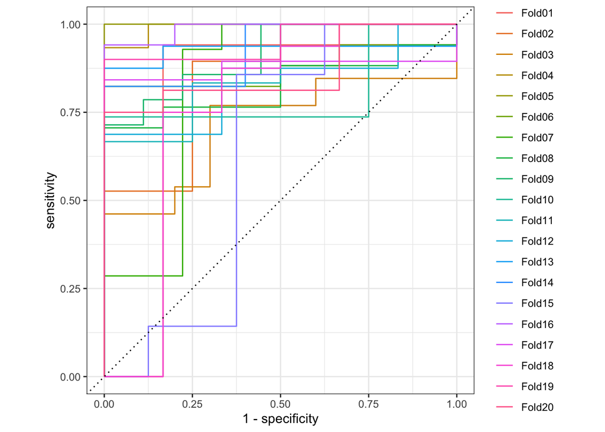

```r
anxiety_glm_cv_preds<-collect_predictions(glm_fit_cv)
anxiety_glm_cv_preds |>
  group_by(id) |>
  roc_curve(truth = gad2_cg_cat, .pred_0) |>
  autoplot()
```

```r
#Prediction on the test data
anxiety.lr.pred.values.test <-  bind_cols(
  truth = anxiety_test$gad2_cg_cat,
  predict(lr_class_fit, anxiety_test),
  predict(lr_class_fit, anxiety_test, type = "prob")
)
anxiety.lr.pred.values.test
```

```
# A tibble: 113 × 4
   truth .pred_class .pred_0 .pred_1
   <fct> <fct>         <dbl>   <dbl>
 1 0     0            0.926   0.0744
 2 0     0            0.926   0.0744
 3 0     0            0.926   0.0744
 4 1     1            0.426   0.574
 5 1     1            0.415   0.585
 6 0     0            0.971   0.0294
 7 0     0            0.926   0.0744
 8 1     1            0.0869  0.913
 9 0     0            0.926   0.0744
10 0     0            0.926   0.0744
# ℹ 103 more rows
```

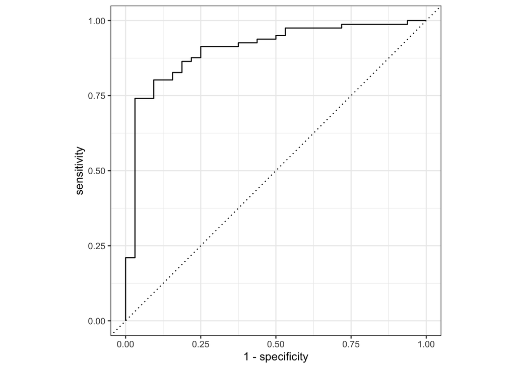

```r
#Plot of ROC curve of prediction on test results
autoplot(roc_curve(anxiety.lr.pred.values.test,
                   truth,
                   .pred_0))
```

```r
#Metrics of prediction on test data
metrics(anxiety.lr.pred.values.test, truth, .pred_class, .pred_0)
```

```
# A tibble: 4 × 3
  .metric     .estimator .estimate
  <chr>       <chr>          <dbl>
1 accuracy    binary         0.841
2 kap         binary         0.592
3 mn_log_loss binary         0.363
4 roc_auc     binary         0.905
```

### 4.3.2 GLM - Depression

```r
#creating training/ testing data
depression_split <- initial_split(depression,
                            prop = 0.80)
depression_split #<450/113/563>
```

```
<Training/Testing/Total>
<450/113/563>
```

```r
depression_train <- training(depression_split)
depression_test <- testing(depression_split)

#glm
set.seed(123)
lr_class_spec<-logistic_reg()|>
  set_engine("glm")

depression_train$phq2_cg_cat <- as.factor(depression_train$phq2_cg_cat)
depression_test$phq2_cg_cat <- as.factor(depression_test$phq2_cg_cat)

lr_class_fit <- lr_class_spec |>
  fit(phq2_cg_cat ~ ., data = depression_train)

## top variables
significant_predictors_depression <- tidy(lr_class_fit$fit) |>
  filter(p.value < 0.05)
print(significant_predictors_depression)
```

```
# A tibble: 4 × 5
  term          estimate std.error statistic     p.value
  <chr>            <dbl>     <dbl>     <dbl>       <dbl>
1 cac11exhaustd   -1.22      0.237     -5.16 0.000000252
2 race_recode     -0.601     0.196     -3.07 0.00213
3 gender_recode   -0.658     0.335     -1.97 0.0494
4 edu_recode      -0.632     0.246     -2.57 0.0101
```

```r
###
depression_glm_wf <- workflow() |>
  add_model(lr_class_spec) |>
  add_formula(phq2_cg_cat ~ .)

# Fit the workflow to the test data
depression_glm_fit <- depression_glm_wf |>
  fit(data = depression_test)

# Generate predictions with probabilities
depression_glm_predicted <- predict(depression_glm_fit, new_data = depression_test, type = "prob")

depression_glm_predicted
```

```
# A tibble: 113 × 2
   .pred_0 .pred_1
     <dbl>   <dbl>
 1  0.0864  0.914
 2  0.0417  0.958
 3  0.958   0.0417
 4  0.182   0.818
 5  0.947   0.0526
 6  0.947   0.0526
 7  0.947   0.0526
 8  0.0141  0.986
 9  0.947   0.0526
10  0.947   0.0526
# ℹ 103 more rows
```

```r
# Combine into a single data frame
depression_glm_pred_values <- bind_cols(
  truth = depression_test$phq2_cg_cat,  # Actual values of the outcome variable
  predict(depression_glm_fit, new_data = depression_test),  # Predicted class labels
  predict(depression_glm_fit, new_data = depression_test, type = "prob")  # Predicted probabilities
)

print(depression_glm_pred_values)
```

```
# A tibble: 113 × 4
   truth .pred_class .pred_0 .pred_1
   <fct> <fct>         <dbl>   <dbl>
 1 1     1            0.0864  0.914
 2 1     1            0.0417  0.958
 3 0     0            0.958   0.0417
 4 1     1            0.182   0.818
 5 0     0            0.947   0.0526
 6 0     0            0.947   0.0526
 7 0     0            0.947   0.0526
 8 1     1            0.0141  0.986
 9 0     0            0.947   0.0526
10 0     0            0.947   0.0526
# ℹ 103 more rows
```

```r
#cross validation  20fold
depression_folds<-vfold_cv(depression_train, v=20)

depression_glm_wf <- workflow ()|>
  add_model(lr_class_spec)|>
  add_formula(phq2_cg_cat ~ .)

depression_glm_fit_cv<-depression_glm_wf |>
  fit_resamples(depression_folds, control=control_resamples(save_pred=TRUE))
collect_metrics(depression_glm_fit_cv)
```

```
# A tibble: 3 × 6
  .metric     .estimator  mean     n std_err .config
  <chr>       <chr>      <dbl> <int>   <dbl> <chr>
1 accuracy    binary     0.789    20  0.0225 Preprocessor1_Model1
2 brier_class binary     0.144    20  0.0109 Preprocessor1_Model1
3 roc_auc     binary     0.829    20  0.0279 Preprocessor1_Model1
```

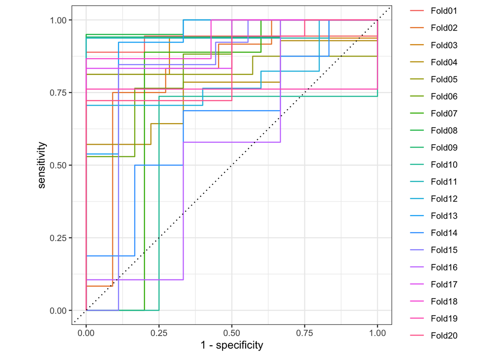

```r
depression_glm_cv_preds<-collect_predictions(depression_glm_fit_cv)
depression_glm_cv_preds |>
  group_by(id) |>
  roc_curve(truth = phq2_cg_cat, .pred_0) |>
  autoplot()
```

```r
#Prediction on the test data
depression.lr.pred.values.test <-  bind_cols(
  truth = depression_test$phq2_cg_cat,
  predict(lr_class_fit, depression_test),
  predict(lr_class_fit, depression_test, type = "prob")
)
depression.lr.pred.values.test
```

```
# A tibble: 113 × 4
   truth .pred_class .pred_0 .pred_1
   <fct> <fct>         <dbl>   <dbl>
 1 1     0             0.805  0.195
 2 1     1             0.280  0.720
 3 0     0             0.841  0.159
 4 1     0             0.846  0.154
 5 0     0             0.918  0.0817
 6 0     0             0.918  0.0817
 7 0     0             0.918  0.0817
 8 1     1             0.234  0.766
 9 0     0             0.918  0.0817
10 0     0             0.918  0.0817
# ℹ 103 more rows
```

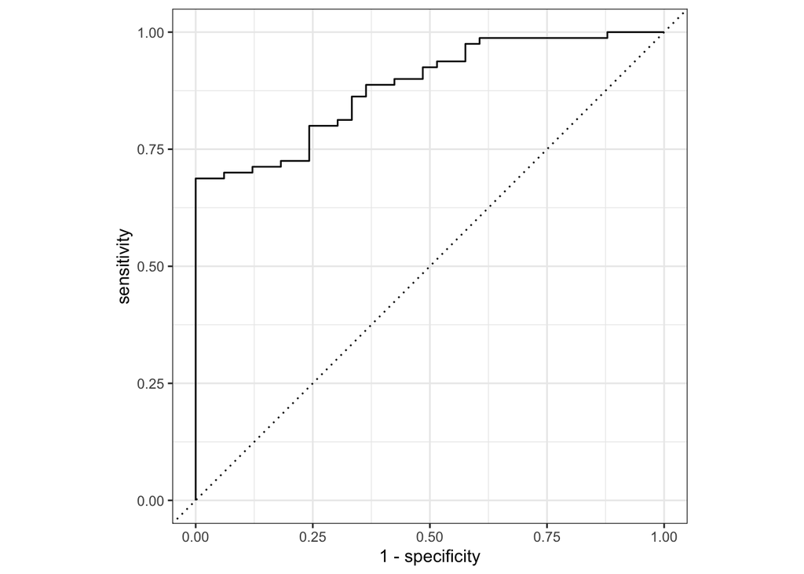

```r
#Plot of ROC curve of prediction on test results
autoplot(roc_curve(depression.lr.pred.values.test,
                   truth,
                   .pred_0))
```

```r
#Metrics of prediction on test data
metrics(depression.lr.pred.values.test, truth, .pred_class, .pred_0)
```

```
# A tibble: 4 × 3
  .metric     .estimator .estimate
  <chr>       <chr>          <dbl>
1 accuracy    binary         0.796
2 kap         binary         0.485
3 mn_log_loss binary         0.407
4 roc_auc     binary         0.884
```

### 4.3.3 Random Forest (RF)- Anxiety

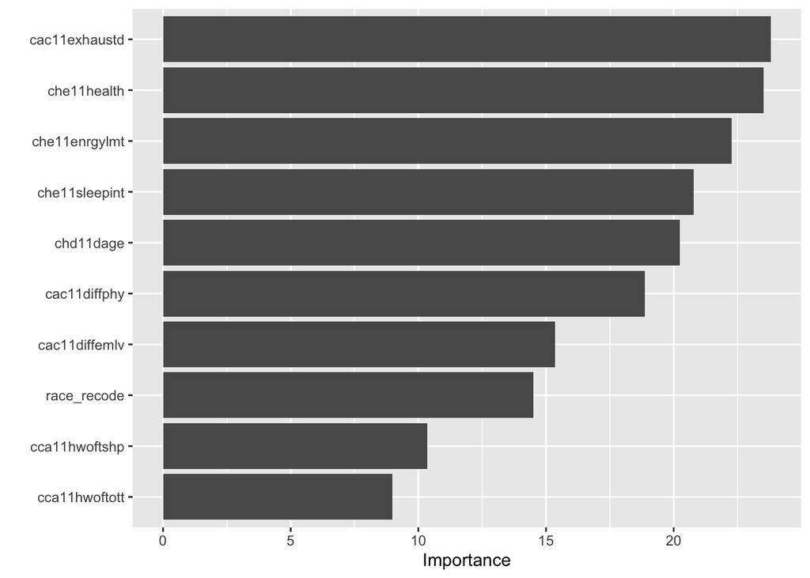

```r
rf_spec<-rand_forest(trees=1000, min_n=5)|>
  set_engine("randomForest", importance=TRUE)|>
  set_mode("classification")

rf_fit<-rf_spec|>
  fit(gad2_cg_cat ~ ., data=anxiety_train)

## top variables
rf_fit|>
  extract_fit_engine()|>
  vip()
```

```r
rf_fit|>
  extract_fit_engine()|>
  importance()|>
  as.data.frame()|>
  arrange(desc(MeanDecreaseGini))
```

```
                        0          1 MeanDecreaseAccuracy MeanDecreaseGini
cac11exhaustd   16.841145 24.7270856           23.8033577        22.572279
chd11dage       17.340658 11.8133522           20.2316386        21.765202
che11sleepint   17.662279 16.0258240           20.7769617        14.789144
che11health     24.222261  2.2254233           23.5125261        12.662581
race_recode     12.238664 10.8134648           14.4937222        10.305499
cac11diffphy    17.274572  9.8407597           18.8664083         9.094697
cac11diffemlv   14.034783  7.8626050           15.3451279         9.018547
che11enrgylmt   20.448463 12.4996833           22.2788947         8.665357
cca11hwoftchs    9.053201  0.8958439            8.8115726         8.534803
cca11hwoftshp   11.802237 -1.3646805           10.3596044         6.321986
edu_recode       7.994810 -3.7634706            6.0229594         5.409190
martstat_recode  5.415706  3.0516985            6.0294712         3.442960
cca11hwoftott   12.988932 -6.1820307            8.9918800         3.233442
gender_recode    6.911161 -3.7889464            4.6724298         2.751433
ew11progneed1    3.193605 -1.5925894            0.9770533         2.216586
```

```r
#20fold CV- rf
anxiety_folds<-vfold_cv(anxiety_train, v=20)
rf_workflow <- workflow() |>
  add_model(rf_spec) |>
  add_formula(gad2_cg_cat ~ .)

rf_fit_cv <- rf_workflow |>
  fit_resamples(anxiety_folds, control=control_resamples(save_pred=TRUE))
collect_metrics(rf_fit_cv)
```

```
# A tibble: 3 × 6
  .metric     .estimator  mean     n std_err .config
  <chr>       <chr>      <dbl> <int>   <dbl> <chr>
1 accuracy    binary     0.824    20 0.0165  Preprocessor1_Model1
2 brier_class binary     0.113    20 0.00746 Preprocessor1_Model1
3 roc_auc     binary     0.898    20 0.0124  Preprocessor1_Model1
```

```r
anxiety_rf_cv_preds<-collect_predictions(rf_fit_cv)
anxiety_rf_cv_preds|>
  group_by(id)|>
  roc_auc(truth = gad2_cg_cat, .pred_0)
```

```
# A tibble: 20 × 4
   id     .metric .estimator .estimate
   <chr>  <chr>   <chr>          <dbl>
 1 Fold01 roc_auc binary         0.862
 2 Fold02 roc_auc binary         0.844
 3 Fold03 roc_auc binary         0.929
 4 Fold04 roc_auc binary         0.955
 5 Fold05 roc_auc binary         0.973
 6 Fold06 roc_auc binary         0.908
 7 Fold07 roc_auc binary         0.869
 8 Fold08 roc_auc binary         0.865
 9 Fold09 roc_auc binary         0.964
10 Fold10 roc_auc binary         0.894
11 Fold11 roc_auc binary         0.8
12 Fold12 roc_auc binary         0.825
13 Fold13 roc_auc binary         0.847
14 Fold14 roc_auc binary         0.875
15 Fold15 roc_auc binary         0.896
16 Fold16 roc_auc binary         0.929
17 Fold17 roc_auc binary         0.986
18 Fold18 roc_auc binary         0.969
19 Fold19 roc_auc binary         0.830
20 Fold20 roc_auc binary         0.941
```

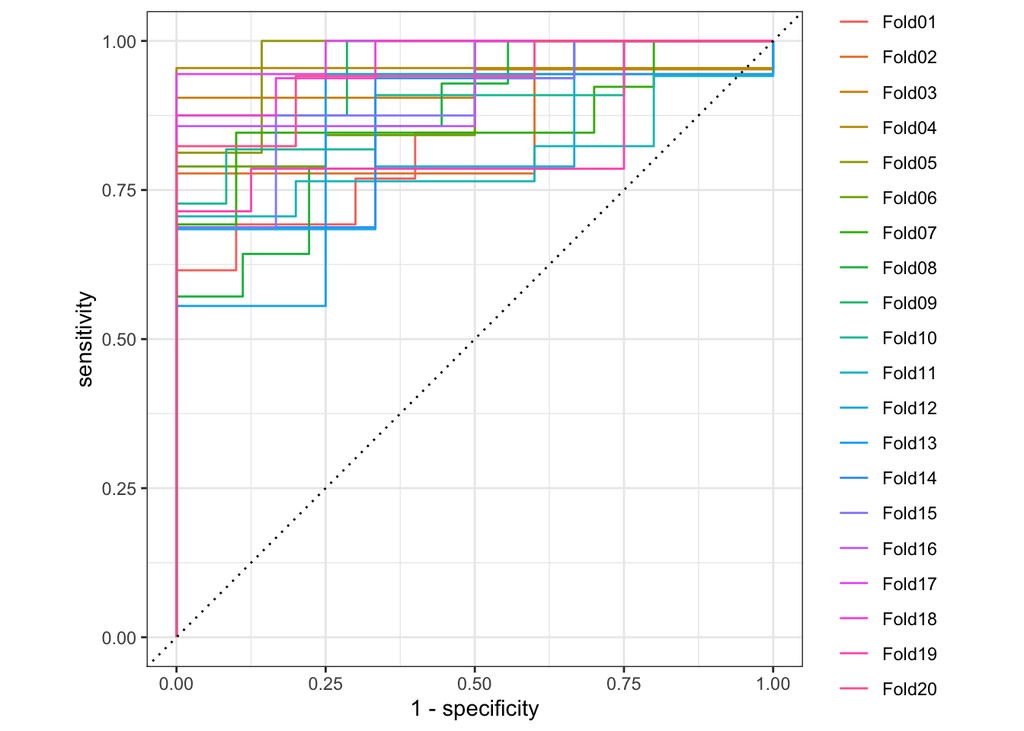

```r
# Plot ROC curve
anxiety_rf_cv_preds |>
  group_by(id)|>
  roc_curve(truth = gad2_cg_cat, .pred_0) |>
  autoplot()
```

```r
# Fit the random forest model on the full training data
anxiety_rf_fit <- rf_spec |>
  fit(gad2_cg_cat ~ ., data = anxiety_train)

anxiety_rf_fit
```

```
parsnip model object


Call:
 randomForest(x = maybe_data_frame(x), y = y, ntree = ~1000, nodesize = min_rows(~5,      x), importance = ~TRUE)
               Type of random forest: classification
                     Number of trees: 1000
No. of variables tried at each split: 3

        OOB estimate of  error rate: 18.89%
Confusion matrix:
    0  1 class.error
0 282 46   0.1402439
1  39 83   0.3196721
```

```r
#testing
anxiety_rf_pred_values <- bind_cols(
  truth = anxiety_test$gad2_cg_cat,  # Actual values of the outcome variable
  predict(anxiety_rf_fit, new_data = anxiety_test),  # Predicted class labels
  predict(anxiety_rf_fit, new_data = anxiety_test, type = "prob")  # Predicted probabilities
)
roc_auc(anxiety_rf_pred_values,
        truth,
        .pred_0)
```

```
# A tibble: 1 × 3
  .metric .estimator .estimate
  <chr>   <chr>          <dbl>
1 roc_auc binary         0.920
```

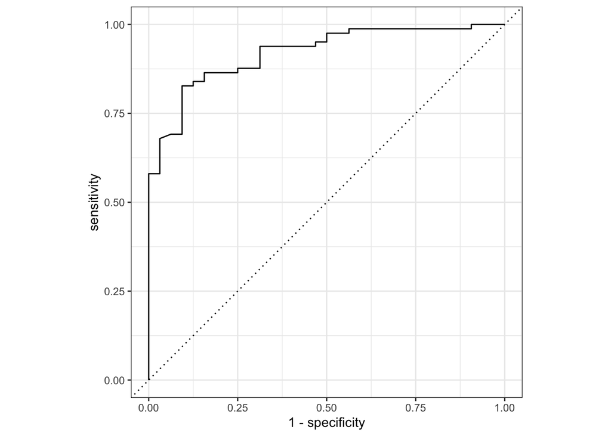

```r
autoplot(roc_curve(anxiety_rf_pred_values,
                   truth,
                   .pred_0))
```

```r
anxiety_rf_fit |>
  extract_fit_engine() |>
  importance()
```

```
                        0          1 MeanDecreaseAccuracy MeanDecreaseGini
cca11hwoftchs    9.114161  0.2144547          8.638984176         8.310629
cca11hwoftshp   13.125149 -3.3381848         10.250861796         6.214090
cca11hwoftott   14.611628 -5.6765351         10.834873494         3.175413
che11enrgylmt   20.559887 13.5992622         23.048009382         8.931050
cac11diffphy    18.026601 11.5486781         20.365521119         9.415522
cac11exhaustd   18.424818 21.6893347         24.554742878        24.077828
cac11diffemlv   13.365988  9.7235902         15.741118351         8.182359
che11health     24.743041  2.5604837         23.813013273        13.587577
che11sleepint   18.114125 11.6891833         20.306462792        14.039453
ew11progneed1    1.468316 -1.1968025         -0.001655434         2.227615
race_recode     10.438878 11.1943874         12.929658566         9.866818
gender_recode    5.555568 -1.3053185          4.343573881         2.751230
edu_recode       6.480619 -1.2931050          5.303692249         5.676081
chd11dage       16.686018 12.0488285         19.341565806        20.462563
martstat_recode  5.584615  2.2374828          6.151268658         3.288719
```

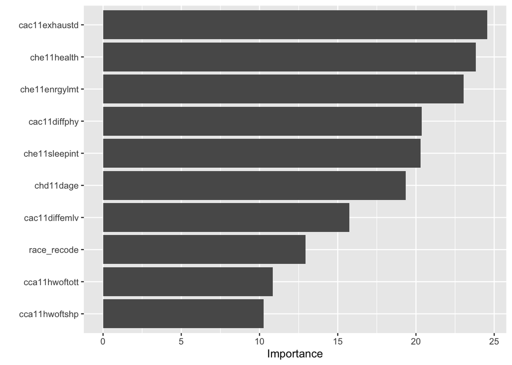

```r
anxiety_rf_fit |>
  extract_fit_engine() |>
  vip()
```

I extracted the fitted random forest model for anxiety (`anxiety_rf_fit`) and calculated the importance of each predictor variable using the `importance()` function. This step helped identify which variables had the most significant impact on the model’s predictions. To further understand these contributions, I visualized the variable importance using the `vip()` function.

These findings highlight the significant factors contributing to anxiety among caregivers, emphasizing the physical and emotional challenges they face.

```r
#20-fold cross validation on rf
anxiety_folds<-vfold_cv(anxiety_train, v=20)

rf_workflow <- workflow() |>
  add_model(rf_spec) |>
  add_formula(gad2_cg_cat ~ .)

rf_fit_cv_anxiety <- rf_workflow |>
  fit_resamples(resamples = anxiety_folds)

collect_metrics(rf_fit_cv_anxiety)
```

```
# A tibble: 3 × 6
  .metric     .estimator  mean     n std_err .config
  <chr>       <chr>      <dbl> <int>   <dbl> <chr>
1 accuracy    binary     0.820    20 0.0183  Preprocessor1_Model1
2 brier_class binary     0.115    20 0.00819 Preprocessor1_Model1
3 roc_auc     binary     0.899    20 0.0143  Preprocessor1_Model1
```

```r
rf_wf_fit_cv_anxiety <- rf_workflow |>
  fit_resamples(
    resamples = anxiety_folds,
    control = control_resamples(save_pred = TRUE)
  )

collect_metrics(rf_wf_fit_cv_anxiety)
```

```
# A tibble: 3 × 6
  .metric     .estimator  mean     n std_err .config
  <chr>       <chr>      <dbl> <int>   <dbl> <chr>
1 accuracy    binary     0.818    20 0.0189  Preprocessor1_Model1
2 brier_class binary     0.115    20 0.00812 Preprocessor1_Model1
3 roc_auc     binary     0.899    20 0.0146  Preprocessor1_Model1
```

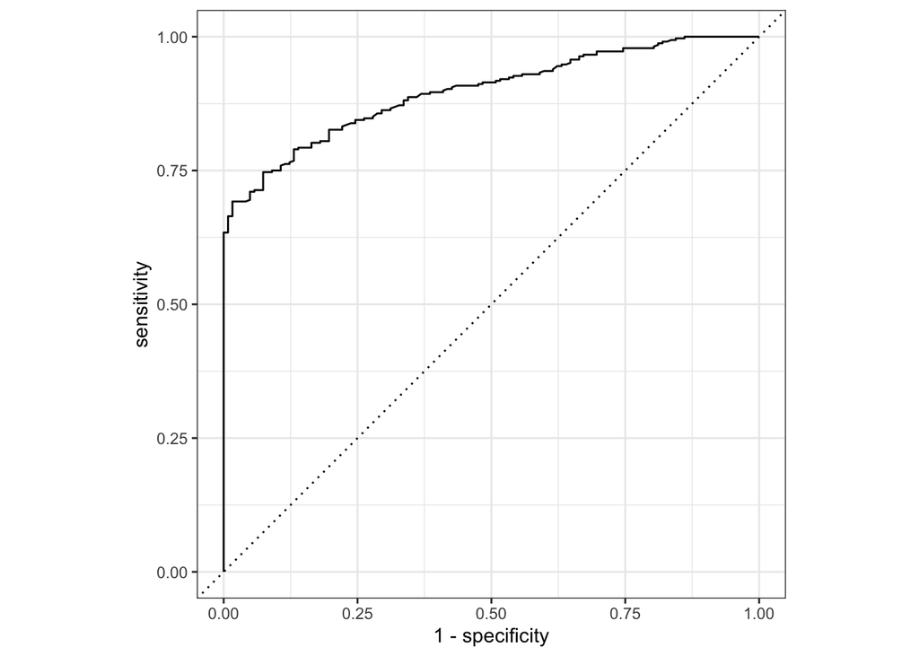

```r
rf_wf_fit_cv_anxiety |>
  collect_predictions() |>
  roc_curve(gad2_cg_cat, .pred_0) |>
  autoplot()
```

```r
# Collect metrics from the resampling results
rf_wf_fit_cv_anxiety_metrics <- collect_metrics(rf_wf_fit_cv_anxiety)
```

### 4.3.4 Random Forest - Depression

[figure not shown]

```r
rf_fit |>
  extract_fit_engine() |>
  vip()
```

```r
rf_spec<-rand_forest(trees=1000, min_n=5)|>
  set_engine("randomForest", importance=TRUE)|>
  set_mode("classification")

depression_rf_fit<-rf_spec|>
  fit(phq2_cg_cat ~ ., data=depression_train)
## top variables
depression_rf_fit |>
  extract_fit_engine() |>
  importance() |>
  as.data.frame() |>
  arrange(desc(MeanDecreaseGini))
```

```
                        0          1 MeanDecreaseAccuracy MeanDecreaseGini
cac11exhaustd   10.865388 25.5660985           19.8409915        19.439402
chd11dage       12.081254 11.3111409           15.1864623        18.448055
race_recode      9.753275 20.8236911           16.6553255        13.494761
che11health     21.941502  6.2704363           22.4493965        13.368114
che11sleepint   11.925597  8.5871377           14.8020595        11.375055
che11enrgylmt   17.846154 13.2730448           20.4932016         8.934018
cac11diffemlv   14.352231  6.9660715           15.4279229         8.231747
cca11hwoftchs   10.727839 -1.2223267            9.1530908         8.197092
cca11hwoftshp   11.522457  1.8099427           11.4897693         7.297414
cac11diffphy    14.897450  4.9269477           15.3466045         7.220981
edu_recode       8.471860  0.9839521            8.4837766         6.074080
cca11hwoftott   13.182959  3.2067144           12.4915293         3.947584
gender_recode    9.682177 -1.8080205            8.4867810         3.302534
martstat_recode  7.685741  2.5360139            7.9784182         3.086613
ew11progneed1    2.921282 -1.7888240            0.9443256         1.938106
```

```r
depression_rf_fit|>
  extract_fit_engine()|>
  importance()|>
  as.data.frame()|>
  arrange(desc(MeanDecreaseGini))
```

```
                        0          1 MeanDecreaseAccuracy MeanDecreaseGini
cac11exhaustd   10.865388 25.5660985           19.8409915        19.439402
chd11dage       12.081254 11.3111409           15.1864623        18.448055
race_recode      9.753275 20.8236911           16.6553255        13.494761
che11health     21.941502  6.2704363           22.4493965        13.368114
che11sleepint   11.925597  8.5871377           14.8020595        11.375055
che11enrgylmt   17.846154 13.2730448           20.4932016         8.934018
cac11diffemlv   14.352231  6.9660715           15.4279229         8.231747
cca11hwoftchs   10.727839 -1.2223267            9.1530908         8.197092
cca11hwoftshp   11.522457  1.8099427           11.4897693         7.297414
cac11diffphy    14.897450  4.9269477           15.3466045         7.220981
edu_recode       8.471860  0.9839521            8.4837766         6.074080
cca11hwoftott   13.182959  3.2067144           12.4915293         3.947584
gender_recode    9.682177 -1.8080205            8.4867810         3.302534
martstat_recode  7.685741  2.5360139            7.9784182         3.086613
ew11progneed1    2.921282 -1.7888240            0.9443256         1.938106
```

```r
#20fold CV- rf
depression_folds<-vfold_cv(depression_train, v=20)
depression_rf_workflow <- workflow() |>
  add_model(rf_spec) |>
  add_formula(phq2_cg_cat ~ .)

depression_rf_fit_cv <- depression_rf_workflow |>
  fit_resamples(depression_folds, control=control_resamples(save_pred=TRUE))
collect_metrics(depression_rf_fit_cv)
```

```
# A tibble: 3 × 6
  .metric     .estimator  mean     n std_err .config
  <chr>       <chr>      <dbl> <int>   <dbl> <chr>
1 accuracy    binary     0.826    20 0.0177  Preprocessor1_Model1
2 brier_class binary     0.120    20 0.00792 Preprocessor1_Model1
3 roc_auc     binary     0.887    20 0.0139  Preprocessor1_Model1
```

```r
depression_rf_cv_preds<-collect_predictions(depression_rf_fit_cv)

depression_rf_cv_preds|>
  group_by(id)|>
  roc_auc(truth = phq2_cg_cat, .pred_0)
```

```
# A tibble: 20 × 4
   id     .metric .estimator .estimate
   <chr>  <chr>   <chr>          <dbl>
 1 Fold01 roc_auc binary         0.855
 2 Fold02 roc_auc binary         0.895
 3 Fold03 roc_auc binary         1
 4 Fold04 roc_auc binary         0.883
 5 Fold05 roc_auc binary         0.938
 6 Fold06 roc_auc binary         0.929
 7 Fold07 roc_auc binary         0.982
 8 Fold08 roc_auc binary         0.931
 9 Fold09 roc_auc binary         0.841
10 Fold10 roc_auc binary         0.911
11 Fold11 roc_auc binary         0.833
12 Fold12 roc_auc binary         0.838
13 Fold13 roc_auc binary         0.893
14 Fold14 roc_auc binary         0.894
15 Fold15 roc_auc binary         0.927
16 Fold16 roc_auc binary         0.752
17 Fold17 roc_auc binary         0.917
18 Fold18 roc_auc binary         0.833
19 Fold19 roc_auc binary         0.918
20 Fold20 roc_auc binary         0.777
```

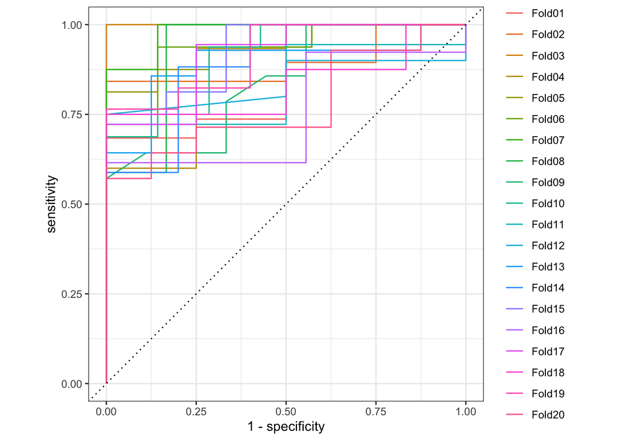

```r
# Plot ROC curve
depression_rf_cv_preds |>
  group_by(id)|>
  roc_curve(truth = phq2_cg_cat, .pred_0) |>
  autoplot()
```

```r
# Fit the random forest model on the full training data
depression_rf_fit <- rf_spec |>
  fit(phq2_cg_cat ~ ., data = depression_train)

depression_rf_fit
```

```
parsnip model object


Call:
 randomForest(x = maybe_data_frame(x), y = y, ntree = ~1000, nodesize = min_rows(~5,      x), importance = ~TRUE)
               Type of random forest: classification
                     Number of trees: 1000
No. of variables tried at each split: 3

        OOB estimate of  error rate: 18.89%
Confusion matrix:
    0  1 class.error
0 301 32   0.0960961
1  53 64   0.4529915
```

```r
#testing
depression_rf_pred_values <- bind_cols(
  truth = depression_test$phq2_cg_cat,  # Actual values of the outcome variable
  predict(depression_rf_fit, new_data = depression_test),  # Predicted class labels
  predict(depression_rf_fit, new_data = depression_test, type = "prob")  # Predicted probabilities
)
roc_auc(depression_rf_pred_values,
        truth,
        .pred_0)
```

```
# A tibble: 1 × 3
  .metric .estimator .estimate
  <chr>   <chr>          <dbl>
1 roc_auc binary         0.883
```

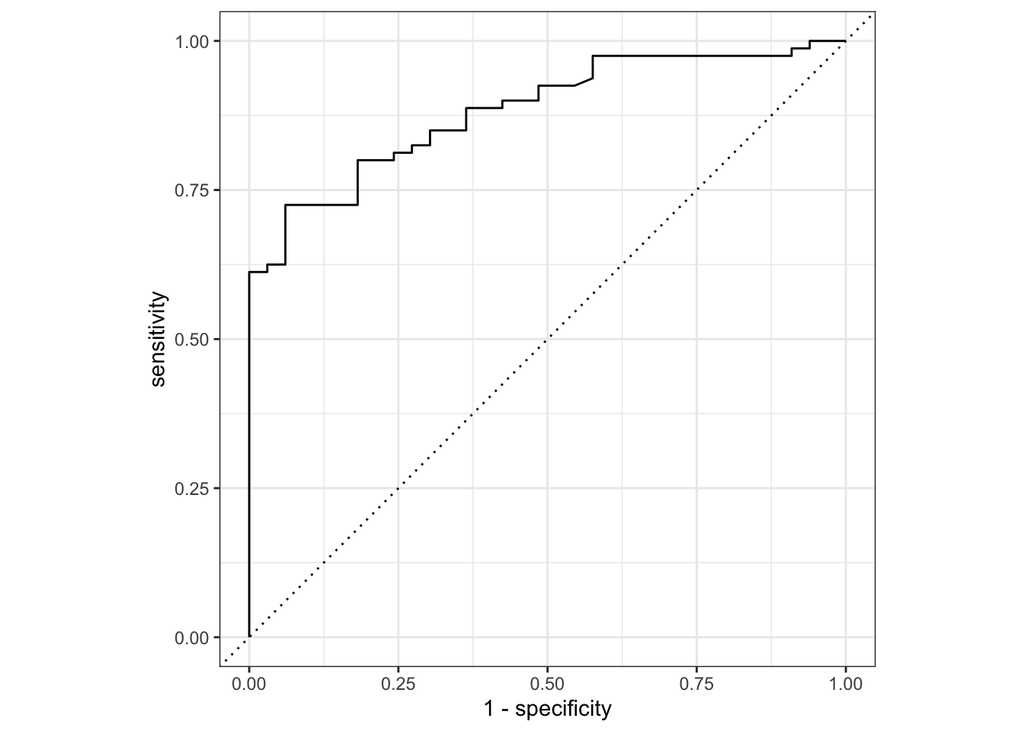

```r
autoplot(roc_curve(depression_rf_pred_values,
                   truth,
                   .pred_0))
```

I collected predictions from the cross-validated random forest model for depression and calculated the ROC AUC for each fold. I then plotted the ROC curve to visualize the model’s performance. After fitting the random forest model on the full training data, I tested it on the test data, calculated the ROC AUC, and plotted the ROC curve for the test predictions.

```r
depression_rf_fit |>
  extract_fit_engine() |>
  importance()
```

```
                        0          1 MeanDecreaseAccuracy MeanDecreaseGini
cca11hwoftchs    9.262055 -1.1300285             8.017559         8.427929
cca11hwoftshp   11.359207 -1.0412234            10.306474         7.032621
cca11hwoftott   12.532188  1.5088331            11.843813         3.740008
che11enrgylmt   17.952644 16.5589554            22.123308         8.615367
cac11diffphy    13.665099  4.0448747            13.788070         7.012969
cac11exhaustd   12.189979 25.1992300            21.543261        19.601864
cac11diffemlv   13.562416  7.6879694            14.969941         7.943109
che11health     20.442166  6.4735190            20.970457        13.723959
che11sleepint   11.025837 11.4272068            14.725029        10.988888
ew11progneed1    1.513254  0.6376639             1.581909         1.905346
race_recode      8.672026 21.2530156            15.883066        13.453339
gender_recode    9.555623 -2.5070129             8.156352         3.328102
edu_recode       9.437549 -0.2970243             8.988941         5.765953
chd11dage       12.184886 13.1510158            16.176949        18.964389
martstat_recode  7.680117  2.5782917             8.053585         3.148567
```

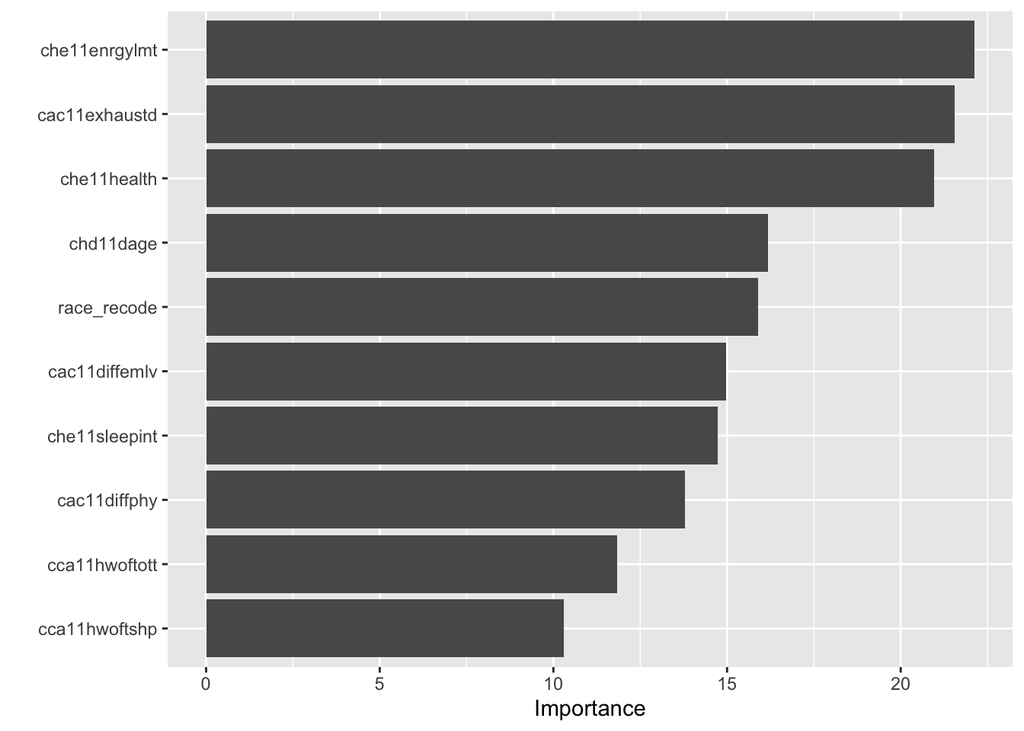

```r
depression_rf_fit |>
  extract_fit_engine() |>
  vip()
```

The analysis revealed that the top five variables influencing depression are similar to those in the anxiety model, but they appear in a different order of importance. Notably, `race_recode` emerged as a more prominent factor in predicting depression compared to anxiety. This suggests that the race of the caregiver plays a significant role in depression, highlighting a key difference in the factors contributing to these two mental health conditions.

This insight is crucial as it underscores the importance of considering racial and ethnic backgrounds when developing interventions and support programs for caregivers. Tailoring support based on race can help address specific challenges and needs, ultimately improving the mental health and well-being of caregivers from diverse backgrounds. This finding emphasizes the need for culturally sensitive approaches in mental health care and support services.

```r
rf_spec_depression<-rand_forest(trees=1000, min_n=5)|>
  set_engine("randomForest", importance=TRUE)|>
  set_mode("classification")

rf_fit_depression<-rf_spec_depression|>
  fit(phq2_cg_cat ~ ., data=depression_train)


#20-fold cross validation on rf
depression_folds<-vfold_cv(depression_train, v=20)

rf_workflow_depression <- workflow() |>
  add_model(rf_spec_depression) |>
  add_formula(phq2_cg_cat ~ .)

rf_fit_cv_depression <- rf_workflow_depression |>
  fit_resamples(resamples = depression_folds)

collect_metrics(rf_fit_cv_depression)
```

```
# A tibble: 3 × 6
  .metric     .estimator  mean     n std_err .config
  <chr>       <chr>      <dbl> <int>   <dbl> <chr>
1 accuracy    binary     0.833    20 0.0217  Preprocessor1_Model1
2 brier_class binary     0.119    20 0.00972 Preprocessor1_Model1
3 roc_auc     binary     0.886    20 0.0171  Preprocessor1_Model1
```

```r
rf_wf_fit_cv_depression <- rf_workflow_depression |>
  fit_resamples(
    resamples = depression_folds,
    control = control_resamples(save_pred = TRUE)
  )

collect_metrics(rf_wf_fit_cv_depression)
```

```
# A tibble: 3 × 6
  .metric     .estimator  mean     n std_err .config
  <chr>       <chr>      <dbl> <int>   <dbl> <chr>
1 accuracy    binary     0.827    20 0.0239  Preprocessor1_Model1
2 brier_class binary     0.119    20 0.00991 Preprocessor1_Model1
3 roc_auc     binary     0.885    20 0.0178  Preprocessor1_Model1
```

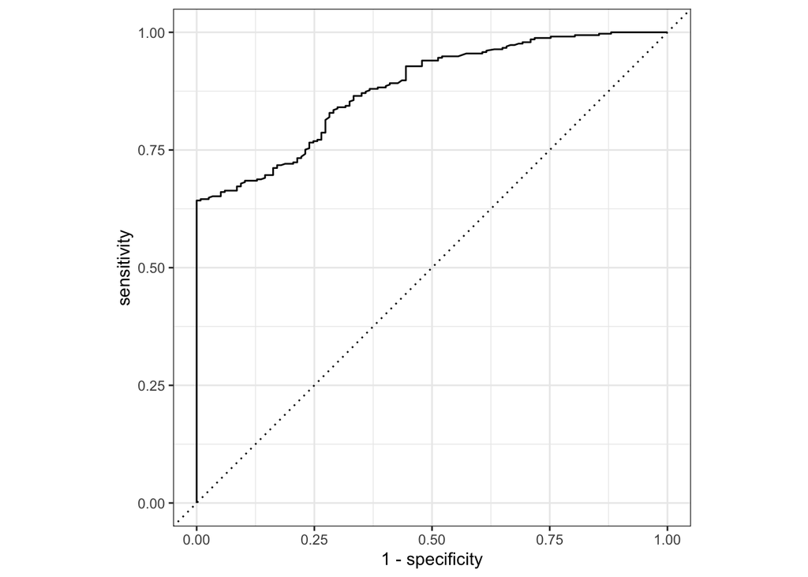

```r
rf_wf_fit_cv_depression |>
  collect_predictions() |>
  roc_curve(phq2_cg_cat, .pred_0) |>
  autoplot()
```

## 4.4 **Comparison of ROC Curves for Logistic Regression and Random Forest Models in Anxiety and Depression Prediction**

### 4.4.1 Anxiety

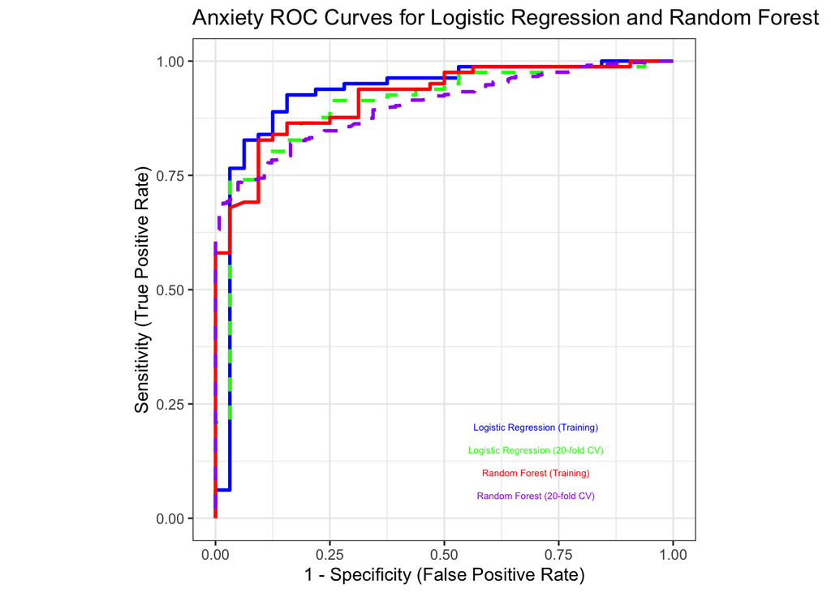

```r
# ROC curve for GLM training set
anxiety_roc_glm_training <- anxiety_glm_pred_values |> roc_curve(truth, .pred_0)
# ROC curve for GLM cross-validation set
anxiety_roc_glm_cv <- anxiety.lr.pred.values.test |> roc_curve(truth, .pred_0)
# ROC curve for RF training set
anxiety_roc_rf_training <- anxiety_rf_pred_values|> roc_curve(truth, .pred_0)
# ROC curve for RF cross-validation set
anxiety_roc_rf_cv <- anxiety_rf_cv_preds |>
  roc_curve(truth = gad2_cg_cat, .pred_0)


ggplot() +
  geom_path(data = anxiety_roc_glm_training, aes(x = 1 - specificity, y = sensitivity),
            color = "blue", linetype = "solid", size = 1, label = "Logistic Regression (Training)") +
  geom_path(data = anxiety_roc_glm_cv, aes(x = 1 - specificity, y = sensitivity),
            color = "green", linetype = "dashed", size = 1, label = "Logistic Regression (20-fold CV)") +
  geom_path(data = anxiety_roc_rf_training, aes(x = 1 - specificity, y = sensitivity),
            color = "red", linetype = "solid", size = 1, label = "Random Forest (Training)") +
  geom_path(data = anxiety_roc_rf_cv, aes(x = 1 - specificity, y = sensitivity),
            color = "purple", linetype = "dashed", size = 1, label = "Random Forest (20-fold CV)") +
coord_equal() +
  theme_bw() +
  labs(title = "Anxiety ROC Curves for Logistic Regression and Random Forest",
       x = "1 - Specificity (False Positive Rate)",
       y = "Sensitivity (True Positive Rate)",
       color = "Model",
       linetype = "Type") +
  theme(legend.position = "right") +
   geom_text(aes(x = 0.7, y = 0.2, label = "Logistic Regression (Training)"),
            color = "blue", size = 2) +
  geom_text(aes(x = 0.7, y = 0.15, label = "Logistic Regression (20-fold CV)"),
            color = "green", size = 2, linetype = "dashed") +
  geom_text(aes(x = 0.7, y = 0.1, label = "Random Forest (Training)"),
            color = "red", size = 2) +
  geom_text(aes(x = 0.7, y = 0.05, label = "Random Forest (20-fold CV)"),
            color = "purple", size = 2, linetype = "dashed")
```

### 4.4.2 Depression

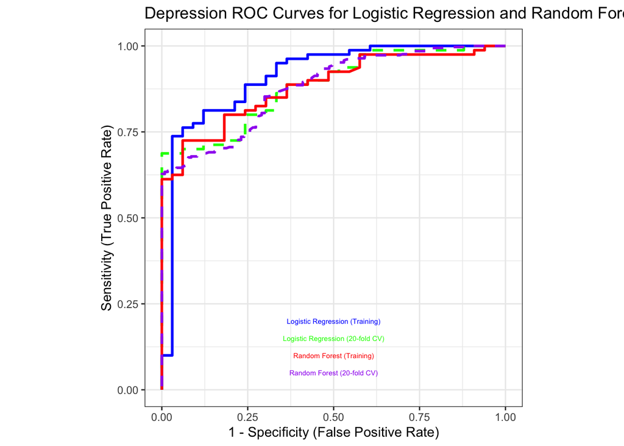

```r
# ROC curve for GLM training set
depression_roc_glm_training <- depression_glm_pred_values |>
  roc_curve(truth = truth, .pred_0)

# ROC curve for GLM cross-validation set
depression_roc_glm_cv <- depression.lr.pred.values.test |>
  roc_curve(truth = truth, .pred_0)

# ROC curve for RF training set
depression_roc_rf_training <- depression_rf_pred_values |>
  roc_curve(truth = truth, .pred_0)

# ROC curve for RF cross-validation set
depression_roc_rf_cv <- depression_rf_cv_preds |>
  roc_curve(truth = phq2_cg_cat, .pred_0)


ggplot() +
  geom_path(data = depression_roc_glm_training, aes(x = 1 - specificity, y = sensitivity),
            color = "blue", linetype = "solid", size = 1, label = "Logistic Regression (Training)") +
  geom_path(data = depression_roc_glm_cv, aes(x = 1 - specificity, y = sensitivity),
            color = "green", linetype = "dashed", size = 1, label = "Logistic Regression (20-fold CV)") +
  geom_path(data = depression_roc_rf_training, aes(x = 1 - specificity, y = sensitivity),
            color = "red", linetype = "solid", size = 1, label = "Random Forest (Training)") +
  geom_path(data = depression_roc_rf_cv, aes(x = 1 - specificity, y = sensitivity),
            color = "purple", linetype = "dashed", size = 1, label = "Random Forest (20-fold CV)") +
coord_equal() +
  theme_bw() +
  labs(title = "Depression ROC Curves for Logistic Regression and Random Forest",
       x = "1 - Specificity (False Positive Rate)",
       y = "Sensitivity (True Positive Rate)",
       color = "Model",
       linetype = "Type") +
  theme(legend.position = "right") +
   geom_text(aes(x = 0.5, y = 0.2, label = "Logistic Regression (Training)"),
            color = "blue", size = 2) +
  geom_text(aes(x = 0.5, y = 0.15, label = "Logistic Regression (20-fold CV)"),
            color = "green", size = 2, linetype = "dashed") +
  geom_text(aes(x = 0.5, y = 0.1, label = "Random Forest (Training)"),
            color = "red", size = 2) +
  geom_text(aes(x = 0.5, y = 0.05, label = "Random Forest (20-fold CV)"),
            color = "purple", size = 2, linetype = "dashed")
```

## 4.5 Implication

The implications of this study emphasize the critical factors contributing to anxiety and depression among caregivers, with a focus on key predictors such as caregivers’ feelings of exhaustion, lack of energy, difficulty with physical help, sleep issues, and health problems. These factors highlight the multifaceted challenges faced by caregivers. Additionally, the discovery that caregiver age is a significant predictor of depression opens new avenues for targeted interventions aimed at improving caregiver mental health.

This research aimed to identify these key predictors and evaluate the predictive accuracy of machine learning algorithms in supporting the early identification of at-risk caregivers. By leveraging advanced techniques, we can enhance early detection, enabling more timely interventions to mitigate mental health risks.

Given that this is an exploratory study, the findings serve as a foundation for future research. Future studies should aim to validate these results with larger, more diverse samples and further explore the underlying mechanisms driving these associations. Longitudinal studies are particularly valuable as they can track changes over time, providing insights into how these factors evolve and their long-term impact on caregivers’ mental health. The use of longitudinal data, such as that from the **National Health and Aging Trends Study (NHATS)** and the **National Study of Caregiving (NSOC)**, will be essential for identifying trends and patterns, enabling a more comprehensive analysis and improving support programs for caregivers.

For future work, I hope to further refine the model by applying a more diverse set of feature selection techniques. This will help identify the most relevant predictors of caregiver mental health outcomes, allowing for a more streamlined and interpretable model. Techniques such as recursive feature elimination (RFE), LASSO (Least Absolute Shrinkage and Selection Operator), or tree-based feature importance methods can help narrow down the feature space, ensuring that only the most significant variables are included in the final model.

By reducing the number of features, the model could potentially improve in performance, interpretability, and generalizability. In addition, focusing on key variables will enable a deeper understanding of the specific factors that most strongly influence caregiver mental health, which could be critical for developing more targeted interventions.

I also plan to explore the interaction effects between selected features, as these interactions might uncover more nuanced relationships that single predictors alone cannot capture. Combining these advanced feature selection techniques with longitudinal data will also allow us to track the impact of specific factors over time and adjust the model accordingly.

**Limitations**:  
Despite the promising results, this study has several limitations. The sample size for both the training and testing sets may not fully capture the diversity of the target population, limiting the generalizability of the findings. While cross-validation reduces overfitting, it does not account for all potential biases or variations within different subgroups. Additionally, missing data, if not properly addressed, could introduce bias or reduce model accuracy. The models used are based on observed data and may not fully capture complex relationships that could emerge with a broader set of variables or external factors. Finally, the reliance on specific features may limit the model’s performance in more dynamic real-world scenarios.

# 5 Conclusion

This exploratory study provides valuable insights into the critical factors influencing anxiety and depression among caregivers and lays the groundwork for future research aimed at improving caregiver mental health. By identifying the key predictors of mental health outcomes and evaluating the predictive power of machine learning algorithms, the study highlights the potential for early identification and intervention for at-risk caregivers. Further validation, particularly through longitudinal studies, is essential to deepen our understanding and inform the development of tailored interventions to support the well-being of caregivers in the long term.